# Spotify2_V6

thibault FUCHEZ

19/03/2021

# Préparation de la base de données.

```r
data<- read.csv("spotify_songs.csv", header = TRUE, sep = ",",stringsAsFactors=T)
```

```r
sum(is.na(data))
```

```
## [1] 15
```

```r
data = na.omit(data)
```

```r
data$key <- recode_factor(data$key,
  "0" = "C",
  "1" = "Db",
  "2" = "D",
  "3" = "Eb",
  "4" = "E",
  "5" = "F",
  "6" = "Gb",
  "7" = "G",
  "8" = "Ab",
  "9" = "A",
  "10" = "Bb",
  "11" = "B"
)

data$mode <- recode_factor(data$mode, "0" = "mineur", "1" = "majeur")
```

```r
data$track_album_release_date <- as.Date(data$track_album_release_date , format= "%Y")
data<- data %>% mutate(year = year(track_album_release_date))
data$years <- cut(data$year, breaks = c(1956,2000,2010,2015,2018,2020), diag.lab=0,
                        labels = c("1956-2000","2001-2010","2011-2015","2016-2018","2019-2020"))
data<-data[,-24]
```

```r
data<- data[!duplicated(data$track_name),]
```

```r
data<-data[,-19]
```

Nous allons prendre comme variable dépendante, la variable `track_popularity`

# Préparation de nos valeurs de test et valeurs d’entrainement

Track_popularity est une variable quantitative, une de nos problématique est de trouver un découpage parlant.

Pour le découpage en 3 modalités : nous pouvons supposer que track_popularity est subjectif. Nous avons décider de proposer plusieurs découpage et de choisir parmi un type de modéle le meilleur decoupage (en aillant préalablmeent choisi les meilleurs paramètres.) Ordonnée.

pour le decoupage en 2 modalité : Les decoupages sont plus extrêmes. Elle sont axées sur différente problématique :

- identifier les plus haute : Au niveau de 70 pour cibler les qualités d’une chanson réellement populaire ( l(objectif sous jacent est de maximiser les vrai haute.)) Pricing
- identifier les basses : Cibler les qualités d’une chanson sous cotés. L’Objectif sous jacent est de maximiser les vrai basses. Eviter des contrats.
- Decoupage naturel : 50/50 qui servera de témoin.

# Découpage en 2 modalités

```r
set.seed((1))
spec=c(train=0.6,test=0.2, valid=0.2)
g=sample(cut(seq(nrow(data)),nrow(data)*cumsum(c(0,spec)), label=names(spec)))
res=split(data,g)
ind2.tr=row.names(res$train)
ind2.te=row.names(res$test)
ind2.v=row.names(res$valid)
```

## Découpage M

On commence par découper la variable track popularity en deux classes autour de la valeur 50.

```r
popularity <- cut(data$track_popularity, c(-1,50,100))
data_pop_M=cbind(popularity,data)
data_pop_M<-data_pop_M[,-5]
data_pop_M$popularity <- recode_factor(data_pop_M$popularity,
"(50,100]" = "haute",
"(-1,50]" = "basse")
data_pop_M<-data_pop_M[,-c(2,3,4,5,6,7,8,9,11)]
```

```r
test_data_M <- data_pop_M[ind2.te,]
train_data_M <- data_pop_M[ind2.tr,]
valid_data_M <- data_pop_M[ind2.v,]
```

### LDA : Linear discriminant analysis

On réalise un LDA sur le jeu des données d’entrainement..

```r
lda_T_M<-lda(popularity~.,data=train_data_M)
```

```r
res_lda_T_M<-predict(lda_T_M,newdata=valid_data_M)
```

#### Matrice de confusion :

On représente la matrice de confusion à partir de laquelle on observe si les prédictions sont conformes à la réalité.

```r
prediction_lda_T_M<-res_lda_T_M$class
Realite_lda_T_M<- valid_data_M$popularity
MatConf_lda_T_M<-table(Realite_lda_T_M,prediction_lda_T_M)
addmargins(MatConf_lda_T_M) %>% kable(caption = "LDA_M : matrice de confusion")%>%kable_styling
```

LDA_M : matrice de confusion

|  | haute | basse | Sum |
| --- | --- | --- | --- |
| haute | 547 | 1214 | 1761 |
| basse | 423 | 2506 | 2929 |
| Sum | 970 | 3720 | 4690 |

```r
round(prop.table(table(Realite_lda_T_M,prediction_lda_T_M),margin=1)*100,1)%>%kable(caption = "Matrice de confusion lda_M avec un seuil à 0,5")%>%kable_styling()
```

Matrice de confusion lda_M avec un seuil à 0,5

|  | haute | basse |
| --- | --- | --- |
| haute | 31.1 | 68.9 |
| basse | 14.4 | 85.6 |

On représente ces données en pourcentage afin de mieux visualiser les individus qui ont été bien ou mal classé. Ici on s’appercoit qu’il y a un déséquilibre car notre modèle prédit l’appartenance à la classe “basse” trop souvent.

#### Choix du meilleur seuil :

Evolution des 3 types d’erreur en fonction de l’évolution du seuil :

Observons l’évolution des trois types d’erreurs en fonction de la probabilité du seuil d’affectation dans la classe haute.

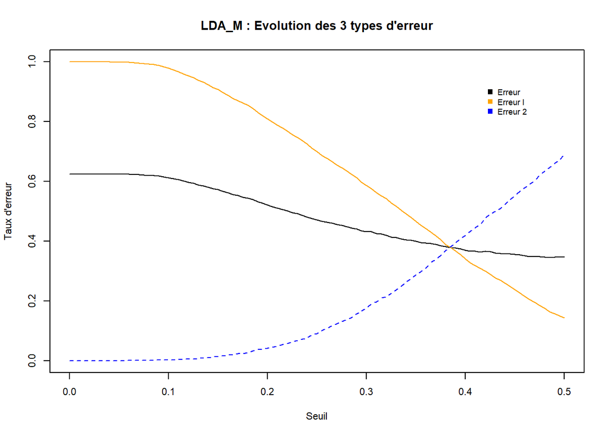

```r
N<-sum(valid_data_M=="basse")
P<-sum(valid_data_M=="haute")
Error_lda_T_M<-NULL
ErrorI_lda_T_M<-NULL
ErrorII_lda_T_M<-NULL
for(i in 1:101){
c<-(i-1)/200
Prediction_lda_T_M<-rep("basse",nrow(valid_data_M))
Prediction_lda_T_M[res_lda_T_M$posterior[,1]>c]<-"haute"
Error_lda_T_M[i]<-sum(Prediction_lda_T_M!=Realite_lda_T_M)/nrow(valid_data_M)
ErrorI_lda_T_M[i]<-sum((Prediction_lda_T_M=="haute")&(Realite_lda_T_M=="basse"))/N
ErrorII_lda_T_M[i]<-sum((Prediction_lda_T_M=="basse")&(Realite_lda_T_M=="haute"))/P
}
par(cex=0.7)
plot((0:100)/200,Error_lda_T_M,type="l",xlim=c(0,0.5),ylim=c(0,1),
ylab="Taux d'erreur",xlab="Seuil")
par(new=T)
plot((0:100)/200,ErrorI_lda_T_M,type="l",xlim=c(0,0.5),ylim=c(0,1),
ylab="",xlab="",xaxt="n",yaxt="n",col="orange")
par(new=T)
plot((0:100)/200,ErrorII_lda_T_M,type="l",xlim=c(0,0.5),ylim=c(0,1),ylab="",xlab="",xaxt="n",yaxt="n",col="blue",lty="dashed")
legend('topright', legend=c("Erreur ", "Erreur I", "Erreur 2"),
       col=c("black","orange", "blue"), pch=15, bty="n", pt.cex=1, cex= 0.8, horiz=FALSE, inset=c(0.1,0.1))
title("LDA_M : Evolution des 3 types d'erreur")
```

On choisit le meilleur seuil en fonction du graphique ci dessus. Comme nous souhaitons une erreur de type 1 et 2 équilibrée, nous choisissons un seuil à 0,38.

On peut maintenant changer le critère de classement dans 1 en le passant de 0,5 à 0,38.

```r
change_seuil<-rep("basse",nrow(valid_data_M))
change_seuil[res_lda_T_M$posterior[,1]>0.38]<-"haute"
round(prop.table(table(Realite_lda_T_M,change_seuil),margin=1)*100,1)%>% kable(caption = "Matrice de confusion lda_M avec un seuil à 0,38") %>% kable_styling()
```

Matrice de confusion lda_M avec un seuil à 0,38

|  | basse | haute |
| --- | --- | --- |
| haute | 36.9 | 63.1 |
| basse | 61.1 | 38.9 |

On compare les matrices de confusions :

```r
N<-sum(valid_data_M=="basse")
P<-sum(valid_data_M=="haute")

Error_lda_T_M0<-sum(Prediction_lda_T_M!=Realite_lda_T_M)/nrow(valid_data_M)
ErrorI_lda_T_M0<-sum((Prediction_lda_T_M=="haute")&(Realite_lda_T_M=="basse"))/N
ErrorII_lda_T_M0<-sum((Prediction_lda_T_M=="basse")&(Realite_lda_T_M=="haute"))/P

Error_lda_T_MS<-sum(change_seuil!=Realite_lda_T_M)/nrow(valid_data_M)
ErrorI_lda_T_MS<-sum((change_seuil=="haute")&(Realite_lda_T_M=="basse"))/N
ErrorII_lda_T_MS<-sum((change_seuil=="basse")&(Realite_lda_T_M=="haute"))/P

matrix_error_lda_M <- as.table(matrix(round(c(Error_lda_T_M0, Error_lda_T_MS, ErrorI_lda_T_M0, ErrorI_lda_T_MS, ErrorII_lda_T_M0, ErrorII_lda_T_MS),3), ncol = 3, nrow = 2))
rownames(matrix_error_lda_M)<- c("seuil= 0,5", "seuil= 0,38")
colnames(matrix_error_lda_M)<- c("Erreur", "Erreur1", "Erreur2")

kable(matrix_error_lda_M, caption = "comparaison des erreurs") %>% kable_styling()
```

comparaison des erreurs

|  | Erreur | Erreur1 | Erreur2 |
| --- | --- | --- | --- |
| seuil= 0,5 | 0.349 | 0.144 | 0.689 |
| seuil= 0,38 | 0.381 | 0.389 | 0.369 |

Un seuil de 38% semble un bon compromis entre les trois types d’erreurs. On choisit le modèle avec le seuil à 0,38.

#### Courbe ROC :

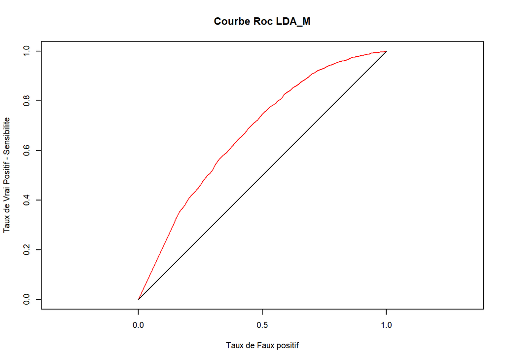

```r
par(cex=0.7)
plot(c(ErrorI_lda_T_M,0),c(1-ErrorII_lda_T_M,0),main="Courbe Roc LDA_M",
ylab="Taux de Vrai Positif - Sensibilite",
xlab="Taux de Faux positif",type="l",asp=1,col="red",xlim=c(0,1),ylim=c(0,1))
segments(0,0,1,1)
```

La courbe ROC n’a pas une forme très convaincante. Notre modèle a une performance relativement correcte.

### QDA : Quadratic linear analysis

#### Matrice de confusion :

```r
qda_T_M<-qda(popularity~., data=train_data_M)
res_qda_T_M<-predict(qda_T_M,newdata = valid_data_M)
prediction_qda_T_M<-res_qda_T_M$class
Realite_qda_T_M<-valid_data_M$popularity
MatConf_qda_T_M<-table(Realite_qda_T_M, prediction_qda_T_M)
addmargins(MatConf_qda_T_M)%>%kable(caption = "Matrice de confusion qda_M")%>%kable_styling()
```

Matrice de confusion qda_M

|  | haute | basse | Sum |
| --- | --- | --- | --- |
| haute | 1110 | 651 | 1761 |
| basse | 1074 | 1855 | 2929 |
| Sum | 2184 | 2506 | 4690 |

```r
round(prop.table(table(Realite_lda_T_M,prediction_qda_T_M),margin=1)*100,1)%>%kable(caption = "Matrice de confusion qda_M en pourcentage")%>%kable_styling()
```

Matrice de confusion qda_M en pourcentage

|  | haute | basse |
| --- | --- | --- |
| haute | 63.0 | 37.0 |
| basse | 36.7 | 63.3 |

#### Choix du meilleur seuil :

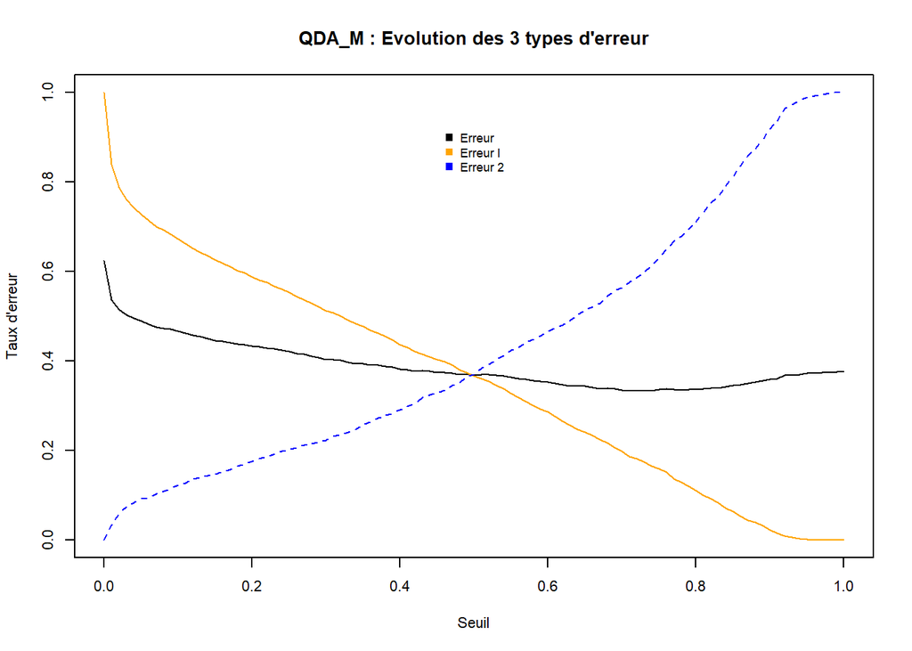

```r
N<-sum(valid_data_M=="basse")
P<-sum(valid_data_M=="haute")
Error_qda_T_M<-NULL
ErrorI_qda_T_M<-NULL
ErrorII_qda_T_M<-NULL
for(i in 1:101){
c<-(i-1)/100
Prediction_qda_T_M<-rep("basse",nrow(valid_data_M))
Prediction_qda_T_M[res_qda_T_M$posterior[,1]>c]<-"haute"
Error_qda_T_M[i]<-sum(Prediction_qda_T_M!=Realite_qda_T_M)/nrow(valid_data_M)
ErrorI_qda_T_M[i]<-sum((Prediction_qda_T_M=="haute")&(Realite_qda_T_M=="basse"))/N
ErrorII_qda_T_M[i]<-sum((Prediction_qda_T_M=="basse")&(Realite_qda_T_M=="haute"))/P
}
par(cex=0.7)
plot((0:100)/100,Error_qda_T_M,type="l",xlim=c(0,1),ylim=c(0,1),
ylab="Taux d'erreur",xlab="Seuil")
par(new=T)
plot((0:100)/100,ErrorI_qda_T_M,type="l",xlim=c(0,1),ylim=c(0,1),
ylab="",xlab="",xaxt="n",yaxt="n",col="orange")
par(new=T)
plot((0:100)/100,ErrorII_qda_T_M,type="l",xlim=c(0,1),ylim=c(0,1),ylab="",xlab="",xaxt="n",yaxt="n",col="blue",lty="dashed")
legend('top', legend=c("Erreur ", "Erreur I", "Erreur 2"),
       col=c("black","orange", "blue"), pch=15, bty="n", pt.cex=1, cex= 0.8, horiz=FALSE, inset=c(0.1,0.1))
title("QDA_M : Evolution des 3 types d'erreur")
```

Il semble inutile de changer le seuil car nous n’obtiendrons pas de meilleurs résultats.En effet, la valeur seuil qui équilibre les trois types d’erreurs est autour de 0,5.

```r
N<-sum(valid_data_M=="basse")
P<-sum(valid_data_M=="haute")
Error_qda_M<-sum(prediction_qda_T_M!=Realite_qda_T_M)/nrow(valid_data_M)
ErrorI_qda_M<-sum((prediction_qda_T_M=="haute")&(Realite_qda_T_M=="basse"))/N
ErrorII_qda_M<-sum((prediction_qda_T_M=="basse")&(Realite_qda_T_M=="haute"))/P
```

#### Courbe Roc :

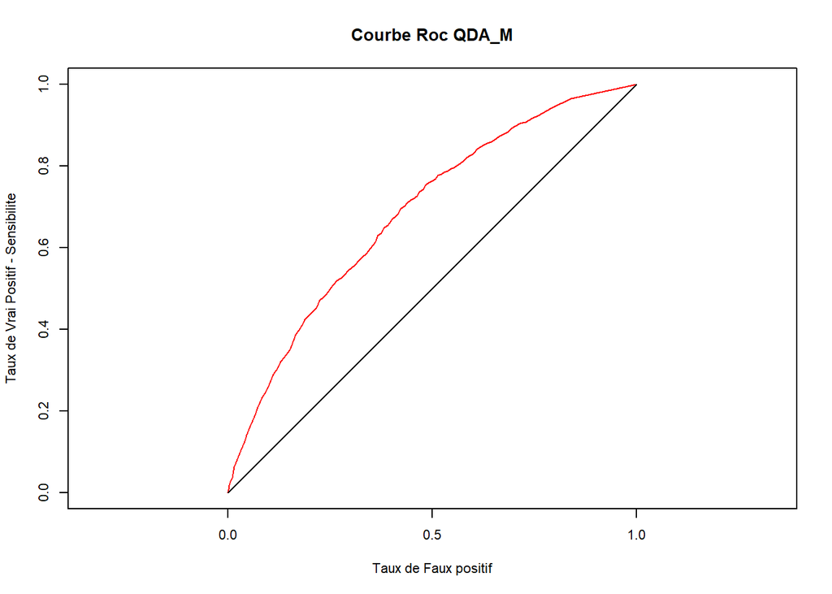

```r
par(cex=0.7)
plot(c(ErrorI_qda_T_M,0),c(1-ErrorII_qda_T_M,0),main="Courbe Roc QDA_M",
ylab="Taux de Vrai Positif - Sensibilite",
xlab="Taux de Faux positif",type="l",asp=1,col="red",xlim=c(0,1),ylim=c(0,1))
segments(0,0,1,1)
```

La courbe ROC de la qda_M est meilleure que pour la lda_M

### KNN

#### Trouvons le meilleur k avec tune :

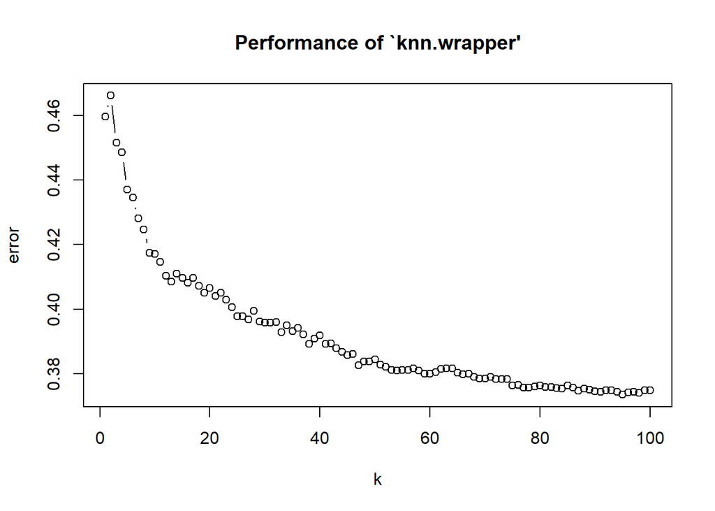

```r
knn_tune_qda_T_M <- tune.knn(x=train_data_M[,-c(1,2,5,7,14)],
                             y = train_data_M[,-c( 2,5,7,14)]$popularity,k=1:100)
plot(knn_tune_qda_T_M)
```

#### Méthode bootsrap pour estimer erreur de prédiction :

```r
Npop_M = nrow(train_data_M)
K <- 70
err.boot_M <- NULL
for (i in 1:100){
      boot.ind_M <- sample(1:Npop_M, Npop_M,replace=TRUE)
      test.ind_M <- setdiff(1:Npop_M, boot.ind_M)
      knn.pred_M <- knn(train = train_data_M[boot.ind_M,-c(1,2,5,7,14)], test = train_data_M[test.ind_M,-c(1,2,5,7,14)],
                      cl = train_data_M[boot.ind_M,1], k = K)
      err.boot_M[i] <- mean(train_data_M[test.ind_M,1]!=knn.pred_M)
}
```

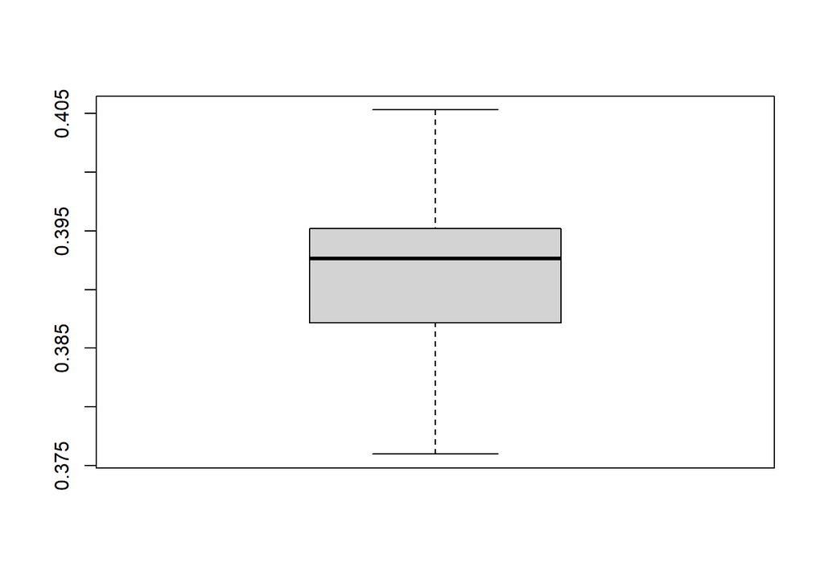

```r
boxplot(err.boot_M)
```

```r
mean(err.boot_M)
```

```
## [1] 0.3913413
```

```r
# on fixe le nombre de voisins à considérer
K <- 70
#réalisation de la prédiction
knn_pred_qda_T_M <- knn(train = train_data_M[,-c(1,2,5,7,14)], test = valid_data_M[,-c(1,2,5,7,14)],
                cl = train_data_M[,"popularity"], k=K)
# prédiction par des probabilités
knn_pred_prob_qda_T_M <- knn(train = train_data_M[,-c(1,2,5,7,14)],
                             test = valid_data_M[,-c(1,2,5,7,14)],
                             cl = train_data_M[,"popularity"], k=K, prob = TRUE)
#matrice de confusion en test
table(valid_data_M[,1],knn_pred_qda_T_M)%>%kable(caption = "matrice de confusion")
```

matrice de confusion

|  | haute | basse |
| --- | --- | --- |
| haute | 32 | 1729 |
| basse | 54 | 2875 |

```r
#taux d'erreur
mean(valid_data_M[,1]!=knn_pred_qda_T_M)
```

```
## [1] 0.3801706
```

Je n’arrive pas à changer le seuil avec les knn. On ne conserve pas ce modèle car la classification est trop mauvaise.

### Arbre de décision :

#### Premier arbre avec paramètres max :

On construit un premier arbre avec les paramètres maximum. C’est à dire qu’on ne limite pas la profondeur et qu’on fixe un paramètre de complexité à 0.

```r
set.seed(1)
control_max_M <- rpart.control(cp = 0, max.depth = 0, minbucket = 1, minsplit = 1)
tree_max_M <- rpart(popularity~. , data = train_data_M, control = control_max_M,
            parms = list(split = "information"))
```

#### Estimation et élagage :

On observe l’évolution du paramètre de complexité en fonction de l’erreur relative de X.

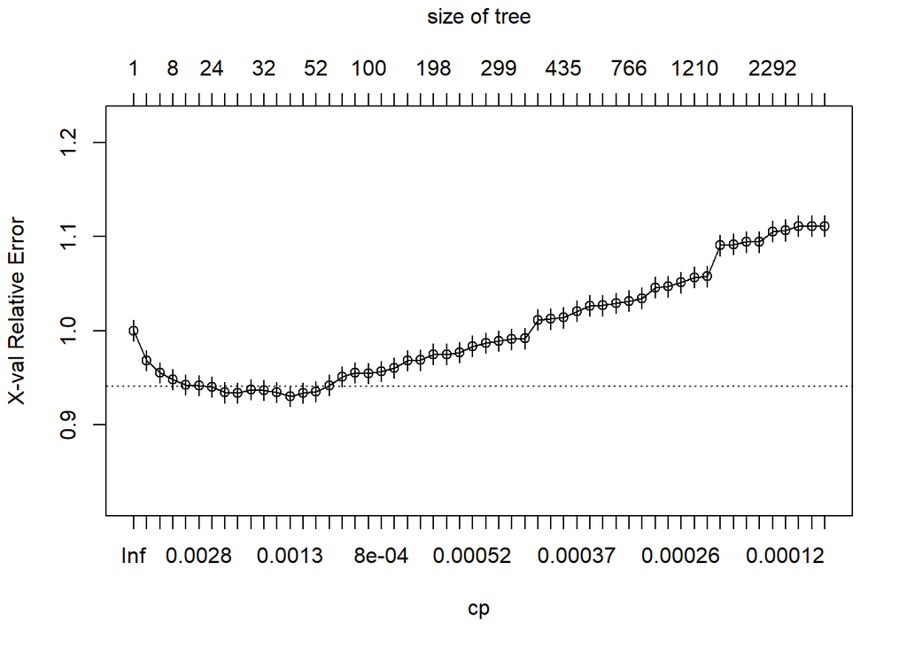

```r
plotcp(tree_max_M)
```

```r
#tree_max_M$cp
#tree_max_M$numresp
```

calcul du meilleur cp :

On calcule d’abord le seuil d’erreur puis on cherche la liste des “CP” qui sont en dessous de cette valeur.

```r
i=which.min(tree_max_M$cp[,"xerror"])
threshold_M=tree_max_M$cp[i,"xerror"]+tree_max_M$cp[i,"xstd"]
j=which(tree_max_M$cp[,"xerror"]<=threshold_M)
tree_max_M$cp[j,"CP"] %>% kable(caption = "") %>% kable_styling()
```

|  | x |
| --- | --- |
| 7 | 0.0022927 |
| 8 | 0.0021972 |
| 9 | 0.0021016 |
| 10 | 0.0015285 |
| 11 | 0.0014648 |
| 12 | 0.0013374 |
| 13 | 0.0012419 |
| 14 | 0.0011941 |
| 15 | 0.0011464 |

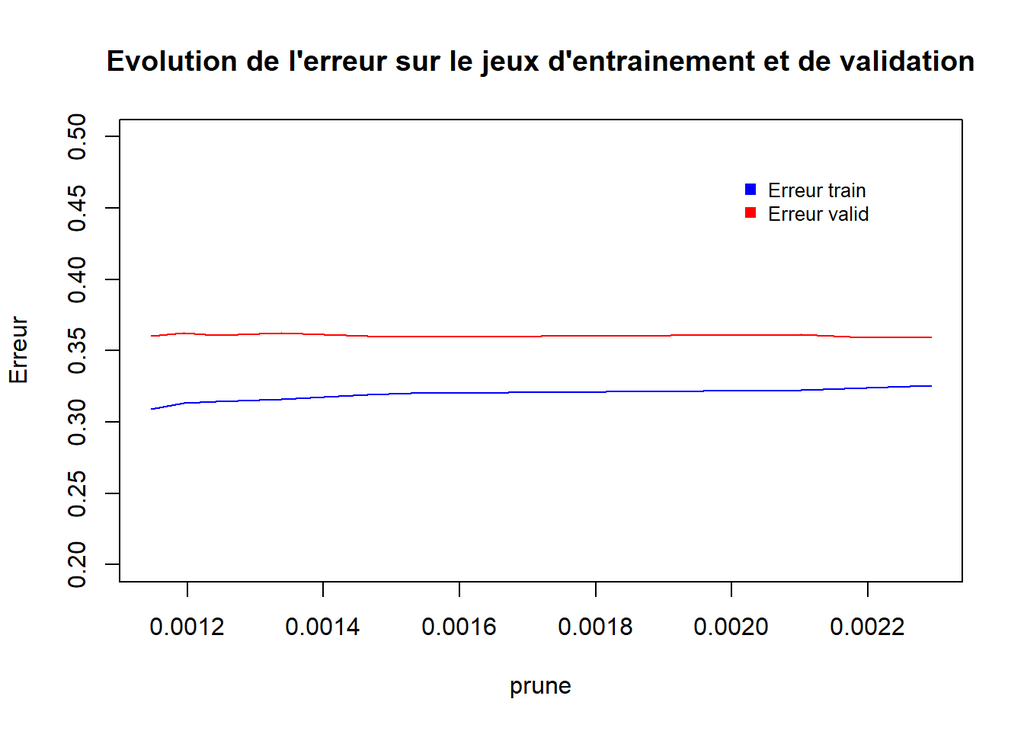

```r
liste_cp_M=as.vector(tree_max_M$cp[j,"CP"])
Error_train_seuil_M<-NULL
Error_valid_seuil_M<-NULL

for(i in 1:length(liste_cp_M)){
  tree_bis_cp_M<- prune(tree_max_M, cp = liste_cp_M[i])
  prediction_cp_M <- predict(tree_bis_cp_M, newdata = train_data_M, type = "class")
  realite_M=train_data_M$popularity
  Error_train_seuil_M[i]<-sum(prediction_cp_M!=realite_M)/nrow(train_data_M)
  prediction_cp_M2 <- predict(tree_bis_cp_M, newdata = valid_data_M, type = "class")
  realite=valid_data_M$popularity
  Error_valid_seuil_M[i]<-sum(prediction_cp_M2!=realite)/nrow(valid_data_M)
}

plot(liste_cp_M,Error_train_seuil_M,type="l",col="blue", xlab = "prune", ylab="Erreur",ylim=c(0.2,0.5))
lines(liste_cp_M,Error_valid_seuil_M,col="red")
legend('topright', legend=c("Erreur train", "Erreur valid"),
       col=c("blue", "red"), pch=15, bty="n", pt.cex=1, cex= 0.8, horiz=FALSE, inset=c(0.1,0.1))

grap_k<-ggplot() + aes(x=liste, y=erreur_valid_seuil_M)+
  geom_line(col="red")+
  labs(title = "L'erreur valid selon le nombre de voisins") + labs(x="k")+ labs(y="Erreur sur les données de validation")+
  theme(
    plot.title = element_text(hjust = 0.5, size = 14))
title("Evolution de l'erreur sur le jeux d'entrainement et de validation")
```

```r
tree_M<- prune(tree_max_M, cp = 0.002292702  )
```

```r
Prediction_tree_M<- predict(tree_M, newdata = valid_data_M, type = "class")
```

```r
control_max_M2 <- rpart.control(cp = 0.002292702  , max.depth = 0, minbucket = 1, minsplit = 1)
tree_Fin_M <- rpart(popularity~. , data = train_data_M, control = control_max_M2,
            parms = list(split = "information"))
```

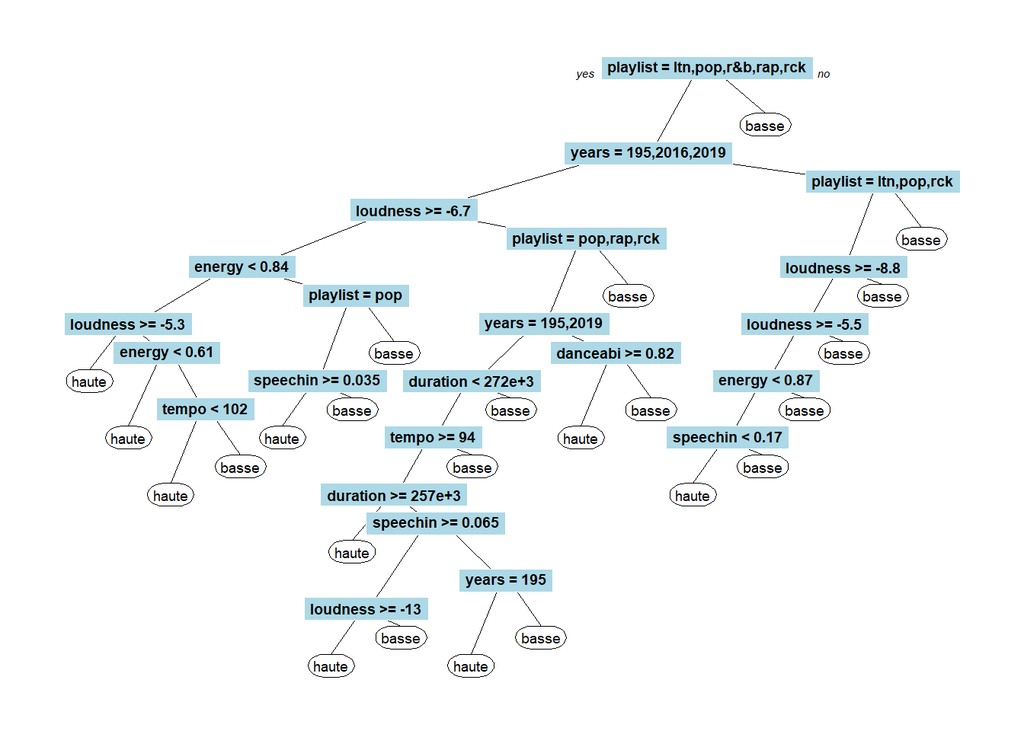

```r
prp(tree_Fin_M,type=0,extra=0,split.box.col="lightblue",cex=0.6)
```

Erreur :

```r
Realite_tree_M<-valid_data_M$popularity
MatConf_tree_M<-table(Realite_tree_M,Prediction_tree_M)
addmargins(MatConf_tree_M)%>% kable(caption = "matrice de confusion TREE_M")%>%kable_styling()
```

matrice de confusion TREE_M

|  | haute | basse | Sum |
| --- | --- | --- | --- |
| haute | 692 | 1069 | 1761 |
| basse | 619 | 2310 | 2929 |
| Sum | 1311 | 3379 | 4690 |

```r
round(prop.table(table(Realite_tree_M,Prediction_tree_M),margin=1)*100,1)%>% kable(caption = "matrice de confusion TREE_M en pourcentage")%>%kable_styling()
```

matrice de confusion TREE_M en pourcentage

|  | haute | basse |
| --- | --- | --- |
| haute | 39.3 | 60.7 |
| basse | 21.1 | 78.9 |

```r
N<-sum(valid_data_M$popularity=="basse")
P<-sum(valid_data_M$popularity=="haute")
Error_tree_M<-NULL
ErrorI_tree_M<-NULL
ErrorII_tree_M<-NULL


Error_tree_M<-sum(Prediction_tree_M!=Realite_tree_M)/nrow(valid_data_M)
ErrorI_tree_M<-sum((Prediction_tree_M=="haute")&(Realite_tree_M=="basse"))/N
ErrorII_tree_M<-sum((Prediction_tree_M=="basse")&(Realite_tree_M=="haute"))/P
```

#### Changement du seuil d’acceptation dans le groupe :

test avec méthode prob pour changer seuil d’acceptation des groupes :

```r
Prediction_tree_M_prob<- predict(tree_M, newdata = valid_data_M, type = "prob")
```

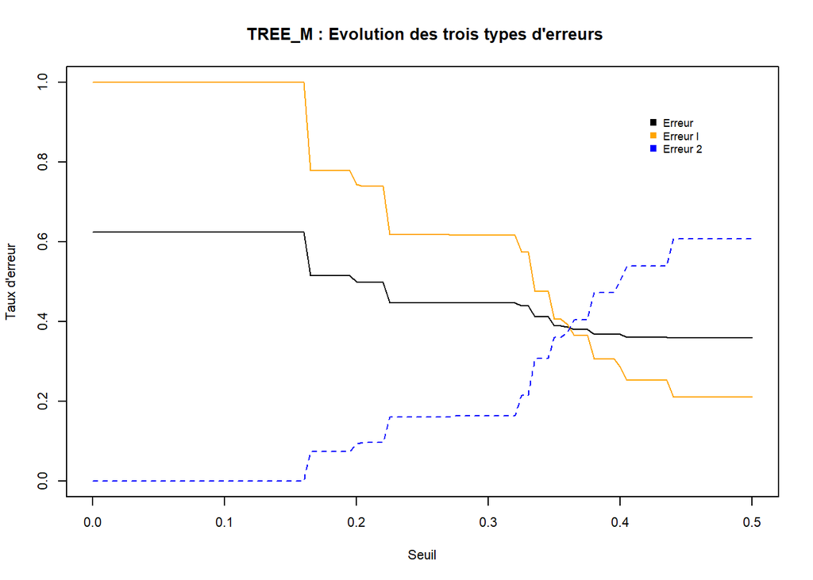

```r
N<-sum(valid_data_M=="basse")
P<-sum(valid_data_M=="haute")
Error_tree_M<-NULL
ErrorI_tree_M<-NULL
ErrorII_tree_M<-NULL
for(i in 1:101){
c<-(i-1)/200
Prediction_tree_MS<-rep("basse",nrow(valid_data_M))
Prediction_tree_MS[Prediction_tree_M_prob[,1]>c]<-"haute"
Error_tree_M[i]<-sum(Prediction_tree_MS!=Realite_lda_T_M)/nrow(valid_data_M)
ErrorI_tree_M[i]<-sum((Prediction_tree_MS=="haute")&(Realite_lda_T_M=="basse"))/N
ErrorII_tree_M[i]<-sum((Prediction_tree_MS=="basse")&(Realite_lda_T_M=="haute"))/P
}
par(cex=0.7)
plot((0:100)/200,Error_tree_M,type="l",xlim=c(0,0.5),ylim=c(0,1),
ylab="Taux d'erreur",xlab="Seuil")
par(new=T)
plot((0:100)/200,ErrorI_tree_M,type="l",xlim=c(0,0.5),ylim=c(0,1),
ylab="",xlab="",xaxt="n",yaxt="n",col="orange")
par(new=T)
plot((0:100)/200,ErrorII_tree_M,type="l",xlim=c(0,0.5),ylim=c(0,1),ylab="",xlab="",xaxt="n",yaxt="n",col="blue",lty="dashed")
legend('topright', legend=c("Erreur ", "Erreur I", "Erreur 2"),
       col=c("black","orange", "blue"), pch=15, bty="n", pt.cex=1, cex= 0.8, horiz=FALSE, inset=c(0.1,0.1))
title(" TREE_M : Evolution des trois types d'erreurs")
```

```r
change_seuil_tree_M<-rep("basse",nrow(valid_data_M))
change_seuil_tree_M[Prediction_tree_M_prob[,1]>0.37]<-"haute"
table(Realite_qda_T_M,change_seuil_tree_M)%>% kable(caption = "matrice de confusion seuil O,37")%>% kable_styling()
```

matrice de confusion seuil O,37

|  | basse | haute |
| --- | --- | --- |
| haute | 712 | 1049 |
| basse | 1860 | 1069 |

```r
N<-sum(valid_data_M=="basse")
P<-sum(valid_data_M=="haute")
change_seuil_tree_M<-rep("basse",nrow(valid_data_M))
change_seuil_tree_M[Prediction_tree_M_prob[,1]>0.37]<-"haute"
MatConf_tree_M2<-table(Realite_qda_T_M,change_seuil_tree_M)

round(prop.table(table(Realite_qda_T_M,Prediction_tree_M),margin=1)*100,1)
```

```
##                Prediction_tree_M
## Realite_qda_T_M haute basse
##           haute  39.3  60.7
##           basse  21.1  78.9
```

```r
Error_tree_M1<-sum(Prediction_tree_M!=Realite_lda_T_M)/nrow(valid_data_M)
ErrorI_tree_M1<-sum((Prediction_tree_M=="haute")&(Realite_lda_T_M=="basse"))/N
ErrorII_tree_M1<-sum((Prediction_tree_M=="basse")&(Realite_lda_T_M=="haute"))/P

Error_tree_M<-sum(change_seuil_tree_M!=Realite_lda_T_M)/nrow(valid_data_M)
ErrorI_tree_M<-sum((change_seuil_tree_M=="haute")&(Realite_lda_T_M=="basse"))/N
ErrorII_tree_M<-sum((change_seuil_tree_M=="basse")&(Realite_lda_T_M=="haute"))/P

matrix_error_tree_M <- as.table(matrix(round(c(Error_tree_M1, Error_tree_M, ErrorI_tree_M1, ErrorI_tree_M, ErrorII_tree_M1, ErrorII_tree_M),3), ncol = 3, nrow = 2))
rownames(matrix_error_tree_M)<- c("seuil= 0,5", "seuil= 0,37 ")
colnames(matrix_error_tree_M)<- c("Erreur", "Erreur1", "Erreur2")

kable(matrix_error_tree_M, caption = "TREE_M : comparaison des erreurs") %>% kable_styling()
```

TREE_M : comparaison des erreurs

|  | Erreur | Erreur1 | Erreur2 |
| --- | --- | --- | --- |
| seuil= 0,5 | 0.36 | 0.211 | 0.607 |
| seuil= 0,37 | 0.38 | 0.365 | 0.404 |

On conserve le modèle avec le seuil à 0,37.

### Random Forest

#### Choix des meilleurs paramètres :

choix des meilleurs min.no.size et mtry avec caret :

```r
ctrlCv <- trainControl(method = "repeatedcv", repeats = 3)
rangerGrid_M <- expand.grid(mtry = c(1, 2, 4, 8, 12), min.node.size = c(10, 50, 100, 150), splitrule = "gini")
# enregistrement d'un cluster avec le package doParallel
library(doParallel)
registerDoParallel(cores = 6)
# lancement de la commande à l'identique
system.time(ranger.caret_M <- train(popularity ~ .,
  data = train_data_M, method = "ranger",
  trControl = ctrlCv, tuneGrid = rangerGrid_M
))
```

```
##    user  system elapsed
##   33.22    0.28 1501.59
```

```r
# fermeture du cluster
stopImplicitCluster()
```

```r
ranger.caret_M$bestTune %>% kable()%>%kable_styling()
```

|  | mtry | splitrule | min.node.size |
| --- | --- | --- | --- |
| 19 | 12 | gini | 100 |

Choix profondeur et nb d’arbres avec les mtry et min.node.size optimaux:

```r
set.seed((1))
nvar=ncol(data_pop_M)-1
err_par_M <- NULL
prof <- c(20,40,60,80,100)
profondeur<-c(200,300,400,500)
i <- 1
for (k in prof){
  for (l in profondeur){
  rfpro_par_M <- randomForest(popularity ~ .,
    data = train_data_M,mtry=12, method = "class", ntree = l,
    parms = list(split = "gini"), maxnodes = k, min.nodesize=100
  )
  err_par_M[i] <- rfpro_par_M$err.rate[l, 1]
  i <- i + 1
  }}

tablo <-as.table(matrix(err_par_M,nrow=4, byrow=FALSE))
colnames(tablo)<-prof
row.names(tablo) <- profondeur
tablo%>%kable()%>%kable_styling()
```

|  | 20 | 40 | 60 | 80 | 100 |
| --- | --- | --- | --- | --- | --- |
| 200 | 0.3475016 | 0.3425261 | 0.3351340 | 0.3358448 | 0.3351340 |
| 300 | 0.3462933 | 0.3407492 | 0.3374085 | 0.3356315 | 0.3366266 |
| 400 | 0.3470751 | 0.3389011 | 0.3354894 | 0.3349207 | 0.3348497 |
| 500 | 0.3483545 | 0.3428104 | 0.3362712 | 0.3360580 | 0.3362002 |

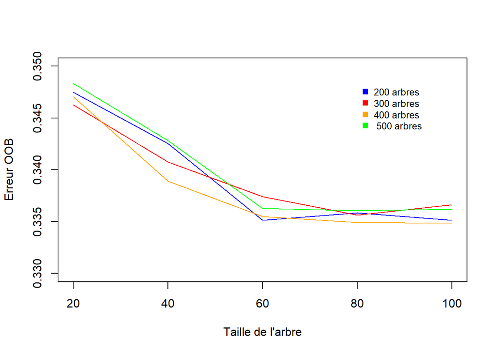

```r
plot(prof,tablo[1,],type="l",col="blue", xlab = "Taille de l'arbre", ylab="Erreur OOB",ylim=c(0.33,0.35))
lines(prof,tablo[2,],col="red")
lines(prof,tablo[3,],col="orange")
lines(prof,tablo[4,],col="green")
legend('topright', legend=c("200 arbres", "300 arbres", "400 arbres", " 500 arbres"),
col=c("blue", "red", "orange", "green"), pch=15, bty="n", pt.cex=1, cex= 0.8, horiz=FALSE, inset=c(0.1,0.1))
```

On lance le modèle final avec les paramètre optimaux.

```r
rf_M <- randomForest(popularity ~ .,
  data = train_data_M, method = "class", mtry=12, method = "class", ntree = 200,
  maxnodes = 60, min.nodesize=100,
  parms = list(split = "gini"), na.action = na.roughfix
)
```

#### graphiques des erreurs en fonctions de certains paramètres :

Les paramètres testés ici ne sont pas forcément ceux retenus par caret. Ces graphiques avait pour but d’étudier plus précisement l’évolution de certains paramètres sous une configuration précise. Nous nous en servions pour affiner nos résultats et comprendre le fonctionnement de la recherche des paramètres optimaux.

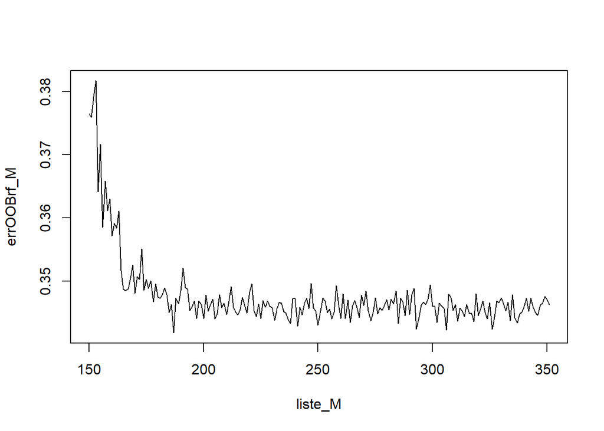

```r
#trouver le meilleur nb d'arbres (ntree)
errOOBrf_M <- NULL
i <- 1
liste_M = c(150:351)
for (k in liste_M){
  rf1_M <- randomForest(popularity ~ .,
    data = train_data_M, method = "class", ntree = k,
    parms = list(split = "gini"), maxnodes = 100, na.action = na.roughfix
  )
  errOOBrf_M[i] <- rf1_M$err.rate[i, 1]
  i <- i + 1
}
plot(liste_M, errOOBrf_M, type = "l")
```

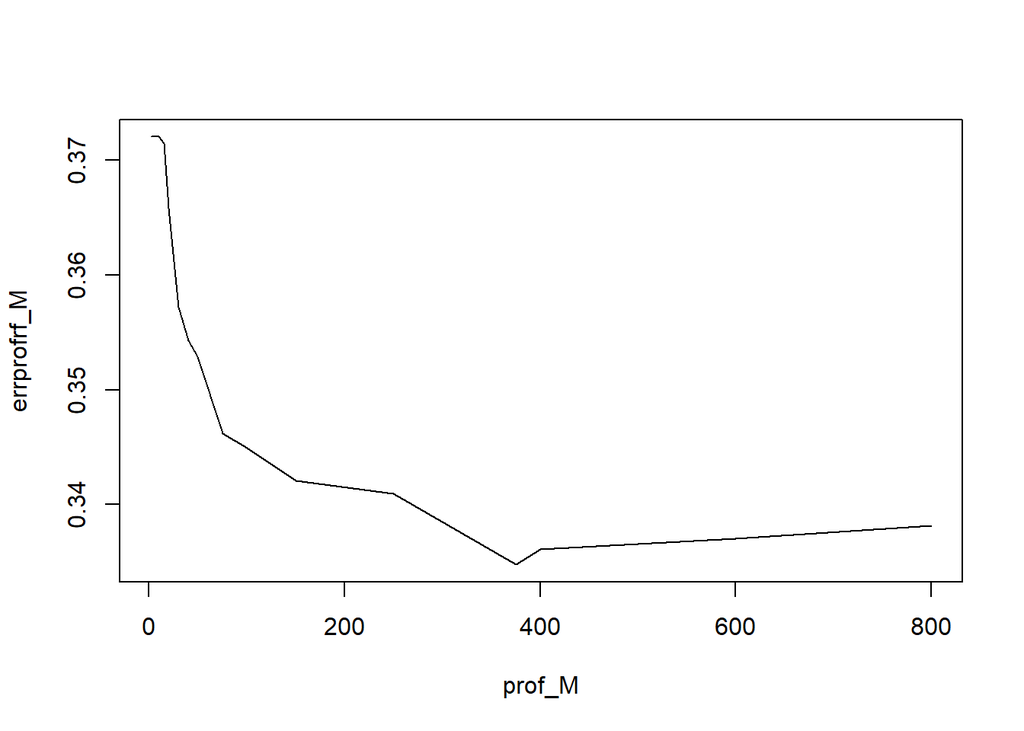

```r
# trouver le meilleur maxnodes
errprofrf_M <- NULL
prof_M <- c(2, 5, 10, 15, 20, 30, 40, 50, 75, 100, 150, 250, 375, 400, 600, 800)
i <- 1
for (k in prof_M) {
  rfpro_M <- randomForest(popularity ~ .,
    data = train_data_M, method = "class", ntree = 200,
    parms = list(split = "gini"), maxnodes = k, na.action = na.roughfix
  )
  errprofrf_M[i] <- rfpro_M$err.rate[200, 1]
  i <- i + 1
}
plot(prof_M, errprofrf_M, type = "l")
```

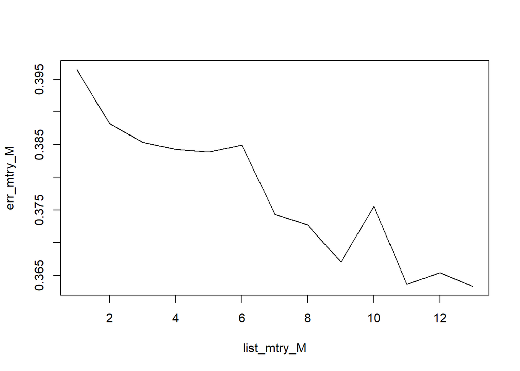

```r
# trouver le meilleur mtry :

err_mtry_M <- NULL
list_mtry_M = c(1:13)
i <- 1
for (k in list_mtry_M) {
  rf_mtry_M <- randomForest(popularity ~ .,
    data = train_data_M, method = "class", ntree = 250,
    parms = list(split = "gini"), maxnodes = 400, mtry = k, na.action = na.roughfix
  )

  err_mtry_M[i] <- rf_mtry_M$err.rate[i, 1]
  i <- i + 1
}
plot(list_mtry_M, err_mtry_M, type = "l")
```

#### Changement du seuil d’acceptation :

```r
prediction_rf_M<- predict(rf_M, newdata = valid_data_M, type = "class")
```

test avec méthode prob pour changer seuil d’acceptation des groupes :

```r
Prediction_rf_M<- predict(rf_M, newdata = valid_data_M, type = "prob")
```

On cherche maintenant le meilleur seuil de classement dans “haute”.

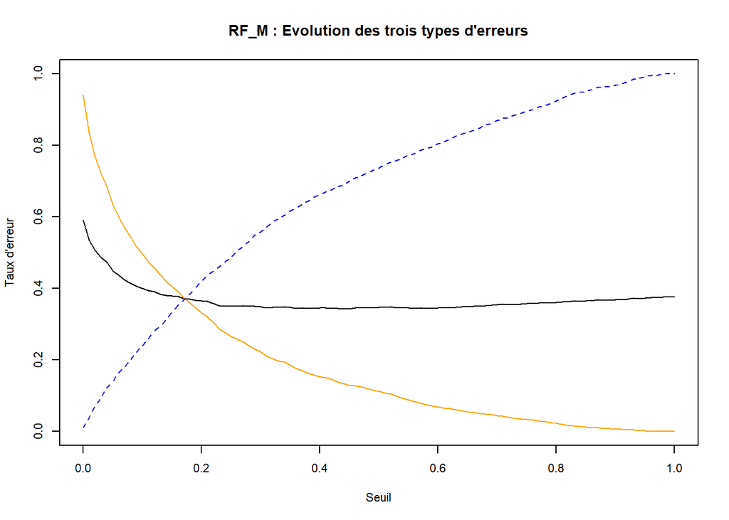

```r
N<-sum(valid_data_M=="basse")
P<-sum(valid_data_M=="haute")
Error_rf_M<-NULL
ErrorI_rf_M<-NULL
ErrorII_rf_M<-NULL
for(i in 1:101){
c<-(i-1)/100
Prediction_rf_MS<-rep("basse",nrow(valid_data_M))
Prediction_rf_MS[Prediction_rf_M[,1]>c]<-"haute"
Error_rf_M[i]<-sum(Prediction_rf_MS!=Realite_lda_T_M)/nrow(valid_data_M)
ErrorI_rf_M[i]<-sum((Prediction_rf_MS=="haute")&(Realite_lda_T_M=="basse"))/N
ErrorII_rf_M[i]<-sum((Prediction_rf_MS=="basse")&(Realite_lda_T_M=="haute"))/P
}
par(cex=0.7)
plot((0:100)/100,Error_rf_M,type="l",xlim=c(0,1),ylim=c(0,1),
ylab="Taux d'erreur",xlab="Seuil")
par(new=T)
plot((0:100)/100,ErrorI_rf_M,type="l",xlim=c(0,1),ylim=c(0,1),
ylab="",xlab="",xaxt="n",yaxt="n",col="orange")
par(new=T)
plot((0:100)/100,ErrorII_rf_M,type="l",xlim=c(0,1),ylim=c(0,1),ylab="",xlab="",xaxt="n",yaxt="n",col="blue",lty="dashed")
title("RF_M : Evolution des trois types d'erreurs")
```

```r
change_seuil_rf_M<-rep("basse",nrow(valid_data_M))
change_seuil_rf_M[Prediction_rf_M[,1]>0.2]<-"haute"
MatConf_rf_M2<-table(Realite_qda_T_M,change_seuil_rf_M)

round(prop.table(table(Realite_qda_T_M,change_seuil_rf_M),margin=1)*100,1)%>% kable(caption= "matrice de confusion seuil 0,2")%>%kable_styling()
```

matrice de confusion seuil 0,2

|  | basse | haute |
| --- | --- | --- |
| haute | 41.9 | 58.1 |
| basse | 66.7 | 33.3 |

```r
round(prop.table(table(Realite_qda_T_M,prediction_rf_M),margin=1)*100,1)%>% kable(caption = "matrice de confusion seuil 0,5")%>%kable_styling()
```

matrice de confusion seuil 0,5

|  | haute | basse |
| --- | --- | --- |
| haute | 26.3 | 73.7 |
| basse | 11.3 | 88.7 |

Les résultats obtenus sont plus équilibré avec le seuil à 0,2.

```r
N<-sum(valid_data_M=="basse")
P<-sum(valid_data_M=="haute")

Error_rf_M1<-sum(prediction_rf_M!=Realite_lda_T_M)/nrow(valid_data_M)
ErrorI_rf_M1<-sum((prediction_rf_M=="haute")&(Realite_lda_T_M=="basse"))/N
ErrorII_rf_M1<-sum((prediction_rf_M=="basse")&(Realite_lda_T_M=="haute"))/P

Error_rf_M<-sum(change_seuil_rf_M!=Realite_lda_T_M)/nrow(valid_data_M)
ErrorI_rf_M<-sum((change_seuil_rf_M=="haute")&(Realite_lda_T_M=="basse"))/N
ErrorII_rf_M<-sum((change_seuil_rf_M=="basse")&(Realite_lda_T_M=="haute"))/P


matrix_error_rf_M <- as.table(matrix(round(c(Error_rf_M1, Error_rf_M, ErrorI_rf_M1, ErrorI_rf_M, ErrorII_rf_M1, ErrorII_rf_M),3), ncol = 3, nrow = 2))
rownames(matrix_error_rf_M)<- c("seuil= 0,5", "seuil= 0,2")
colnames(matrix_error_rf_M)<- c("Erreur", "Erreur1", "Erreur2")

kable(matrix_error_rf_M, caption = "comparaison des erreurs") %>% kable_styling()
```

comparaison des erreurs

|  | Erreur | Erreur1 | Erreur2 |
| --- | --- | --- | --- |
| seuil= 0,5 | 0.347 | 0.113 | 0.737 |
| seuil= 0,2 | 0.365 | 0.333 | 0.419 |

On conserve le modèle avec le seuil à 0,2.

### Comparaison entre les différents types de modèle :

On a selectionné lda_M_seuil38, qda_M_seuil5, tree_M_seuil37 et rf_M_seuil2.

Comparons les différents modèles à l’aide des données test.

```r
N<-sum(test_data_M=="basse")
P<-sum(test_data_M=="haute")
res_lda_seuil<-predict(lda_T_M,newdata=test_data_M, type ="prob")
Prediction_M_seuilLDA<-rep("basse",nrow(test_data_M))
Prediction_M_seuilLDA[res_lda_seuil$posterior[,1]>0.38]<-"haute"
Error_lda_seuil<-sum(Prediction_M_seuilLDA!=test_data_M$popularity)/nrow(test_data_M)
ErrorI_lda_seuil<-sum((Prediction_M_seuilLDA=="haute")&(test_data_M$popularity=="basse"))/N
ErrorII_lda_seuil<-sum((Prediction_M_seuilLDA=="basse")&(test_data_M$popularity=="haute"))/P
```

```r
N<-sum(test_data_M=="basse")
P<-sum(test_data_M=="haute")
res_qda_seuil<-predict(qda_T_M,newdata=test_data_M)
Error_qda_seuil<-sum(res_qda_seuil$class!=test_data_M$popularity)/nrow(test_data_M)
ErrorI_qda_seuil<-sum((res_qda_seuil$class=="haute")&(test_data_M$popularity=="basse"))/N
ErrorII_qda_seuil<-sum((res_qda_seuil$class=="basse")&(test_data_M$popularity=="haute"))/P
```

```r
N<-sum(test_data_M=="basse")
P<-sum(test_data_M=="haute")
best_rpart_control_M <- rpart.control(cp = 0.002292702, max.depth = 0,
                              minbucket = 1, minsplit = 1)
best_tree_M <- rpart(popularity ~ .,
  data = train_data_M, control = best_rpart_control_M,
  parms = list(split = "information")
)

res_best_tree_M<-predict(best_tree_M,newdata=test_data_M, type = "prob")
Prediction_M_seuilTREE<-rep("basse",nrow(test_data_M))
Prediction_M_seuilTREE[res_best_tree_M[,1]>0.37]<-"haute"
Error_best_tree_M<-sum(Prediction_M_seuilTREE!=test_data_M$popularity)/nrow(test_data_M)
ErrorI_best_tree_M<-sum((Prediction_M_seuilTREE=="haute")&(test_data_M$popularity=="basse"))/N
ErrorII_best_tree_M<-sum((Prediction_M_seuilTREE=="basse")&(test_data_M$popularity=="haute"))/P
```

```r
N<-sum(test_data_M=="basse")
P<-sum(test_data_M=="haute")
best_rf_M <-randomForest(popularity ~ .,
  data = train_data_M, method = "class", mtry=12, method = "class", ntree = 200,
  maxnodes = 60, min.nodesize=100,
  parms = list(split = "gini"), na.action = na.roughfix
)

res_best_rf_M<-predict(best_rf_M,newdata=test_data_M, type ="prob")
Prediction_M_seuilRF<-rep("basse",nrow(test_data_M))
Prediction_M_seuilRF[res_best_rf_M[,1]>0.2]<-"haute"
Error_best_rf_M<-sum(Prediction_M_seuilRF!=test_data_M$popularity)/nrow(test_data_M)
ErrorI_best_rf_M<-sum((Prediction_M_seuilRF=="haute")&(test_data_M$popularity=="basse"))/N
ErrorII_best_rf_M<-sum((Prediction_M_seuilRF=="basse")&(test_data_M$popularity=="haute"))/P
```

```r
erreursM <- matrix(c(Error_lda_seuil, Error_qda_seuil, Error_best_tree_M, Error_best_rf_M,
                    ErrorI_lda_seuil, ErrorI_qda_seuil, ErrorI_best_tree_M, ErrorI_best_rf_M,
                    ErrorII_lda_seuil, ErrorII_qda_seuil, ErrorII_best_tree_M, ErrorII_best_rf_M), byrow = FALSE, ncol = 3)
colnames(erreursM) <- c("Erreur globale", "Erreur type I", "Erreur type 2")
rownames(erreursM) <- c("lda38", "qda50", "tree37", "rf20")
erreursM %>% knitr::kable(digits = 3) %>%
  kableExtra::kable_styling()
```

|  | Erreur globale | Erreur type I | Erreur type 2 |
| --- | --- | --- | --- |
| lda38 | 0.368 | 0.386 | 0.340 |
| qda50 | 0.352 | 0.357 | 0.345 |
| tree37 | 0.377 | 0.356 | 0.413 |
| rf20 | 0.339 | 0.313 | 0.381 |

## Découpage bas :

```r
popularity <- cut(data$track_popularity, c(-1,30,100))
data_pop_B=cbind(popularity,data)
data_pop_B<-data_pop_B[,-5]
data_pop_B$popularity <- recode_factor(data_pop_B$popularity,
"(30,100]" = "haute",
"(-1,30]" = "basse")
data_pop_B<-data_pop_B[,-c(2,3,4,5,6,7,8,9,11)]
```

```r
test_data_B <- data_pop_B[ind2.te,]
train_data_B <- data_pop_B[ind2.tr,]
valid_data_B <- data_pop_B[ind2.v,]
```

### LDA : Linear discriminant analysis

```r
lda_T_B<-lda(popularity~.,data=train_data_B)
```

```r
res_lda_T_B<-predict(lda_T_B,newdata=valid_data_B)
```

#### Matrice de confusion :

```r
prediction_lda_T_B<-res_lda_T_B$class
Realite_lda_T_B<- valid_data_B$popularity
MatConf_lda_T_B<-table(Realite_lda_T_B,prediction_lda_T_B)

round(prop.table(table(Realite_lda_T_B,prediction_lda_T_B),margin=1)*100,1)%>%kable(caption = "LDA_B : matrice de confusion")%>% kable_styling()
```

LDA_B : matrice de confusion

|  | haute | basse |
| --- | --- | --- |
| haute | 92.1 | 7.9 |
| basse | 75.4 | 24.6 |

#### Choix du meilleur seuil :

Evolution des 3 types d’erreur en fonction de l’évolution du seuil :

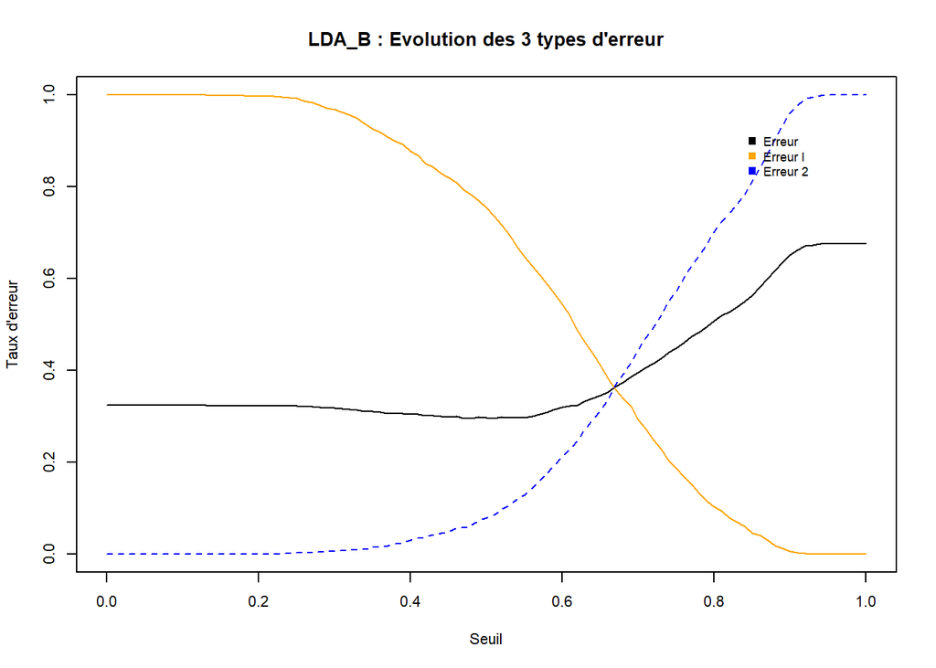

```r
N<-sum(valid_data_B=="basse")
P<-sum(valid_data_B=="haute")
Error_lda_T_B<-NULL
ErrorI_lda_T_B<-NULL
ErrorII_lda_T_B<-NULL
for(i in 1:101){
c<-(i-1)/100
Prediction_lda_T_B<-rep("basse",nrow(valid_data_B))
Prediction_lda_T_B[res_lda_T_B$posterior[,1]>c]<-"haute"
Error_lda_T_B[i]<-sum(Prediction_lda_T_B!=Realite_lda_T_B)/nrow(valid_data_B)
ErrorI_lda_T_B[i]<-sum((Prediction_lda_T_B=="haute")&(Realite_lda_T_B=="basse"))/N
ErrorII_lda_T_B[i]<-sum((Prediction_lda_T_B=="basse")&(Realite_lda_T_B=="haute"))/P
}
par(cex=0.7)
plot((0:100)/100,Error_lda_T_B,type="l",xlim=c(0,1),ylim=c(0,1),
ylab="Taux d'erreur",xlab="Seuil")
par(new=T)
plot((0:100)/100,ErrorI_lda_T_B,type="l",xlim=c(0,1),ylim=c(0,1),
ylab="",xlab="",xaxt="n",yaxt="n",col="orange")
par(new=T)
plot((0:100)/100,ErrorII_lda_T_B,type="l",xlim=c(0,1),ylim=c(0,1),ylab="",xlab="",xaxt="n",yaxt="n",col="blue",lty="dashed")
legend('topright', legend=c("Erreur ", "Erreur I", "Erreur 2"),
       col=c("black","orange", "blue"), pch=15, bty="n", pt.cex=1, cex= 0.8, horiz=FALSE, inset=c(0.1,0.1))
title("LDA_B : Evolution des 3 types d'erreur")
```

Choix du meilleur seuil :

```r
change_seuil_lda_T_B2<-rep("basse",nrow(valid_data_M))
change_seuil_lda_T_B2[res_lda_T_B$posterior[,1]>0.7]<-"haute"
MatConf_lda_T_B2<-table(Realite_lda_T_B,change_seuil_lda_T_B2)

round(prop.table(table(Realite_lda_T_B,change_seuil_lda_T_B2),margin=1)*100,1)%>%kable(caption = "LDA_B : matrice de confusion seuil 0.65")%>% kable_styling()
```

|  | basse | haute |
| --- | --- | --- |
| haute | 44.4 | 55.6 |
| basse | 70.7 | 29.3 |

On compare les matrices de confusions et les erreurs :

```r
N<-sum(valid_data_B=="basse")
P<-sum(valid_data_B=="haute")
round(prop.table(table(Realite_lda_T_B,change_seuil_lda_T_B2),margin=1)*100,1)
```

```
##                change_seuil_lda_T_B2
## Realite_lda_T_B basse haute
##           haute  44.4  55.6
##           basse  70.7  29.3
```

```r
round(prop.table(table(Realite_lda_T_B,prediction_lda_T_B),margin=1)*100,1)
```

```
##                prediction_lda_T_B
## Realite_lda_T_B haute basse
##           haute  92.1   7.9
##           basse  75.4  24.6
```

```r
Error_lda_T_B0<-sum(prediction_lda_T_B!=Realite_lda_T_B)/nrow(valid_data_B)
ErrorI_lda_T_B0<-sum((prediction_lda_T_B=="haute")&(Realite_lda_T_B=="basse"))/N
ErrorII_lda_T_B0<-sum((prediction_lda_T_B=="basse")&(Realite_lda_T_B=="haute"))/P

Error_lda_T_BS<-sum(change_seuil_lda_T_B2!=Realite_lda_T_B)/nrow(valid_data_B)
ErrorI_lda_T_BS<-sum((change_seuil_lda_T_B2=="haute")&(Realite_lda_T_B=="basse"))/N
ErrorII_lda_T_BS<-sum((change_seuil_lda_T_B2=="basse")&(Realite_lda_T_B=="haute"))/P

matrix_error_lda_B <- as.table(matrix(round(c(Error_lda_T_B0, Error_lda_T_BS, ErrorI_lda_T_B0, ErrorI_lda_T_BS, ErrorII_lda_T_B0, ErrorII_lda_T_BS),3), ncol = 3, nrow = 2))
rownames(matrix_error_lda_B)<- c("seuil= 0,5", "seuil= 0,7")
colnames(matrix_error_lda_B)<- c("Erreur", "Erreur1", "Erreur2")

kable(matrix_error_lda_B, caption = "comparaison des erreurs") %>% kable_styling()
```

comparaison des erreurs

|  | Erreur | Erreur1 | Erreur2 |
| --- | --- | --- | --- |
| seuil= 0,5 | 0.297 | 0.754 | 0.079 |
| seuil= 0,7 | 0.395 | 0.293 | 0.444 |

On choisit de perdre en précision globale pour mieux prédire les “basses” avec un seuil de 0,7.On a donc valorisé une erreur de type 1 faible.

#### Courbe ROC

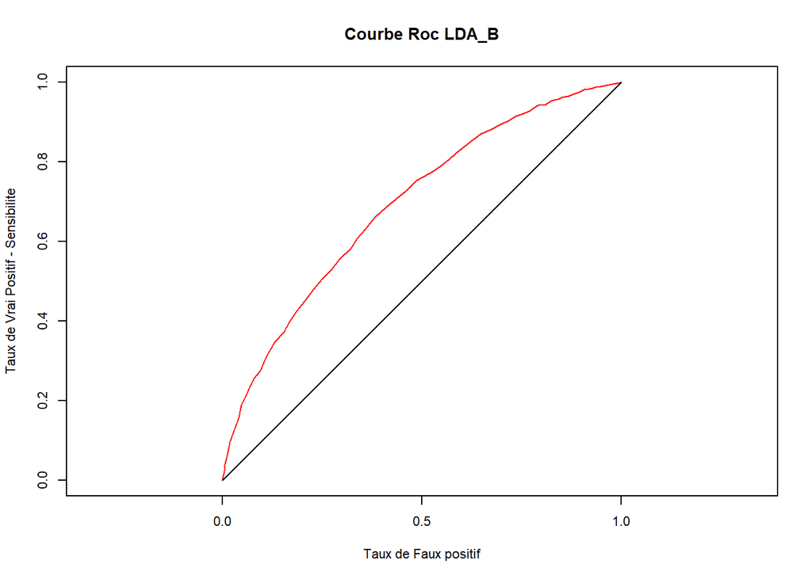

```r
par(cex=0.7)
plot(c(ErrorI_lda_T_B,0),c(1-ErrorII_lda_T_B,0),main="Courbe Roc LDA_B",
ylab="Taux de Vrai Positif - Sensibilite",
xlab="Taux de Faux positif",type="l",asp=1,col="red",xlim=c(0,1),ylim=c(0,1))
segments(0,0,1,1)
```

### QDA : Quadratic linear analysis

#### Matrice de confusion :

```r
qda_T_B<-qda(popularity~., data=train_data_B)
res_qda_T_B<-predict(qda_T_B,newdata = valid_data_B)
prediction_qda_T_B<-res_qda_T_B$class
Realite_qda_T_B<-valid_data_B$popularity
MatConf_qda_T_B<-table(Realite_qda_T_B, prediction_qda_T_B)

round(prop.table(table(Realite_lda_T_B,prediction_qda_T_B),margin=1)*100,1) %>%kable(caption = "QDA_B : matrice de confusion")%>% kable_styling()
```

QDA_B : matrice de confusion

|  | haute | basse |
| --- | --- | --- |
| haute | 76.1 | 23.9 |
| basse | 51.3 | 48.7 |

#### Choix du meilleur seuil :

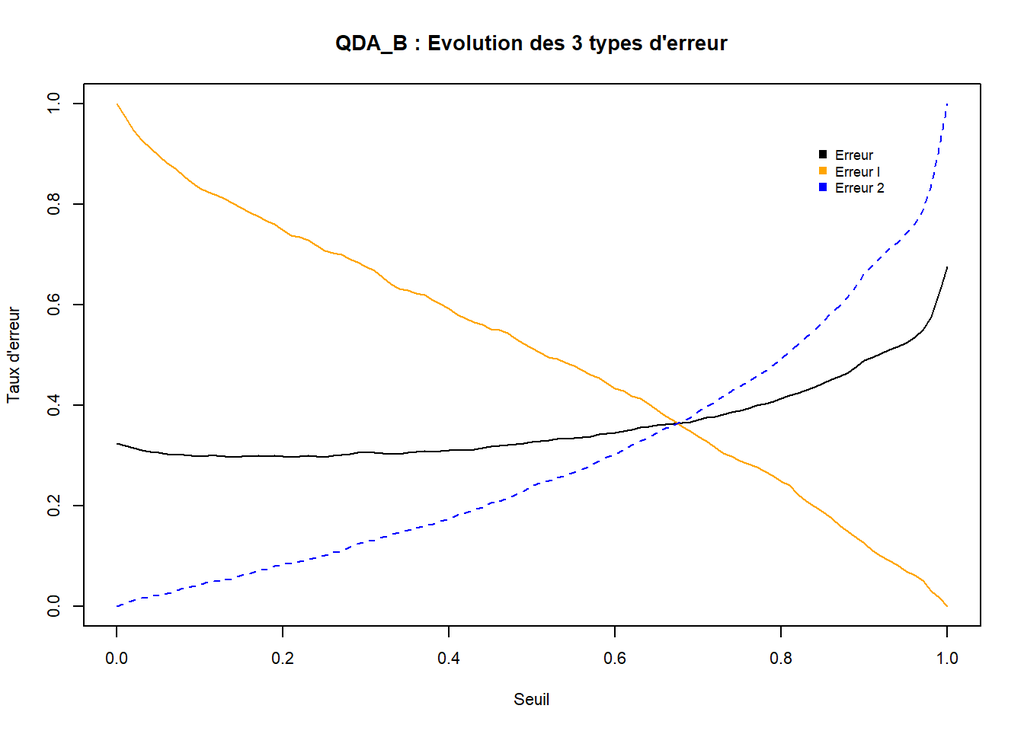

```r
N<-sum(valid_data_B=="basse")
P<-sum(valid_data_B=="haute")
Error_qda_T_B<-NULL
ErrorI_qda_T_B<-NULL
ErrorII_qda_T_B<-NULL
for(i in 1:101){
c<-(i-1)/100
Prediction_qda_T_B<-rep("basse",nrow(valid_data_B))
Prediction_qda_T_B[res_qda_T_B$posterior[,1]>c]<-"haute"
Error_qda_T_B[i]<-sum(Prediction_qda_T_B!=Realite_qda_T_B)/nrow(valid_data_B)
ErrorI_qda_T_B[i]<-sum((Prediction_qda_T_B=="haute")&(Realite_qda_T_B=="basse"))/N
ErrorII_qda_T_B[i]<-sum((Prediction_qda_T_B=="basse")&(Realite_qda_T_B=="haute"))/P
}
par(cex=0.7)
plot((0:100)/100,Error_qda_T_B,type="l",xlim=c(0,1),ylim=c(0,1),
ylab="Taux d'erreur",xlab="Seuil")
par(new=T)
plot((0:100)/100,ErrorI_qda_T_B,type="l",xlim=c(0,1),ylim=c(0,1),
ylab="",xlab="",xaxt="n",yaxt="n",col="orange")
par(new=T)
plot((0:100)/100,ErrorII_qda_T_B,type="l",xlim=c(0,1),ylim=c(0,1),ylab="",xlab="",xaxt="n",yaxt="n",col="blue",lty="dashed")
legend('topright', legend=c("Erreur ", "Erreur I", "Erreur 2"),
       col=c("black","orange", "blue"), pch=15, bty="n", pt.cex=1, cex= 0.8, horiz=FALSE, inset=c(0.1,0.1))
title("QDA_B : Evolution des 3 types d'erreur")
```

On choisit un seuil à 0,72.

```r
change_seuil_qda_B<-rep("basse",nrow(valid_data_B))
change_seuil_qda_B[res_qda_T_B$posterior[,1]>0.72]<-"haute"
MatConf_qda_T_B2<-table(Realite_qda_T_B,change_seuil_qda_B)

round(prop.table(table(Realite_qda_T_B,change_seuil_qda_B),margin=1)*100,1) %>%kable(caption = "QDA_B : matrice de confusion en %, seuil 0,72")%>% kable_styling()
```

QDA_B : matrice de confusion en %, seuil 0,72

|  | basse | haute |
| --- | --- | --- |
| haute | 40.6 | 59.4 |
| basse | 68.3 | 31.7 |

On compare les matrices de confusions :

```r
N<-sum(valid_data_B=="basse")
P<-sum(valid_data_B=="haute")
round(prop.table(table(Realite_lda_T_B,change_seuil_qda_B),margin=1)*100,1)
```

```
##                change_seuil_qda_B
## Realite_lda_T_B basse haute
##           haute  40.6  59.4
##           basse  68.3  31.7
```

```r
round(prop.table(table(Realite_lda_T_B,prediction_qda_T_B),margin=1)*100,1)
```

```
##                prediction_qda_T_B
## Realite_lda_T_B haute basse
##           haute  76.1  23.9
##           basse  51.3  48.7
```

```r
Error_qda_T_B0<-sum(prediction_qda_T_B!=Realite_lda_T_B)/nrow(valid_data_B)
ErrorI_qda_T_B0<-sum((prediction_qda_T_B=="haute")&(Realite_lda_T_B=="basse"))/N
ErrorII_qda_T_B0<-sum((prediction_qda_T_B=="basse")&(Realite_lda_T_B=="haute"))/P

Error_qda_T_BS<-sum(change_seuil_qda_B!=Realite_lda_T_B)/nrow(valid_data_B)
ErrorI_qda_T_BS<-sum((change_seuil_qda_B=="haute")&(Realite_lda_T_B=="basse"))/N
ErrorII_qda_T_BS<-sum((change_seuil_qda_B=="basse")&(Realite_lda_T_B=="haute"))/P

matrix_error_qda_B <- as.table(matrix(round(c(Error_qda_T_B0, Error_qda_T_BS, ErrorI_qda_T_B0, ErrorI_qda_T_BS, ErrorII_qda_T_B0, ErrorII_qda_T_BS),3), ncol = 3, nrow = 2))
rownames(matrix_error_qda_B)<- c("seuil= 0,5", "seuil= 0,7")
colnames(matrix_error_qda_B)<- c("Erreur", "Erreur1", "Erreur2")

kable(matrix_error_qda_B, caption = "comparaison des erreurs") %>% kable_styling()
```

comparaison des erreurs

|  | Erreur | Erreur1 | Erreur2 |
| --- | --- | --- | --- |
| seuil= 0,5 | 0.328 | 0.513 | 0.239 |
| seuil= 0,7 | 0.377 | 0.317 | 0.406 |

Ici on perd aussi legerement de précision globale pour mieux cibler les “basses” (erreur de type 1)

#### Courbe ROC :

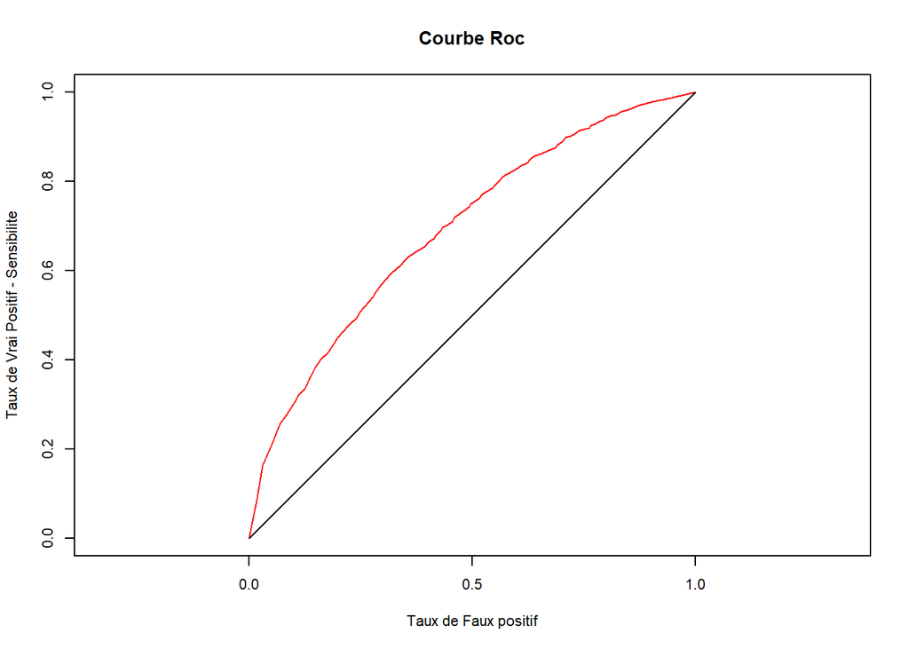

```r
par(cex=0.7)
plot(c(ErrorI_qda_T_B,0),c(1-ErrorII_qda_T_B,0),main="Courbe Roc",
ylab="Taux de Vrai Positif - Sensibilite",
xlab="Taux de Faux positif",type="l",asp=1,col="red",xlim=c(0,1),ylim=c(0,1))
segments(0,0,1,1)
```

### KNN

#### Trouvons le meilleur k avec tune :

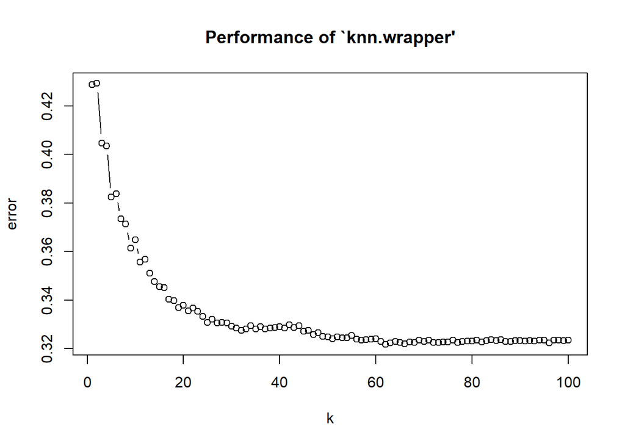

```r
knn_tune_qda_T_B <- tune.knn(x=train_data_B[,-c(1,2,5,7,14)],
                             y = train_data_B[,-c( 2,5,7,14)]$popularity,k=1:100)
plot(knn_tune_qda_T_B)
```

#### Méthode bootsrap pour estimer erreur de prédiction :

```r
Npop_B = nrow(train_data_B)
K <- 70
err.boot_B <- NULL
for (i in 1:100){
      boot.ind_B <- sample(1:Npop_B, Npop_B,replace=TRUE)
      test.ind_B <- setdiff(1:Npop_B, boot.ind_B)
      knn.pred_B <- knn(train = train_data_B[boot.ind_B,-c(1,2,5,7,14)], test = train_data_B[test.ind_B,-c(1,2,5,7,14)],
                      cl = train_data_B[boot.ind_B,1], k = K)
      err.boot_B[i] <- mean(train_data_B[test.ind_B,1]!=knn.pred_B)
}
```

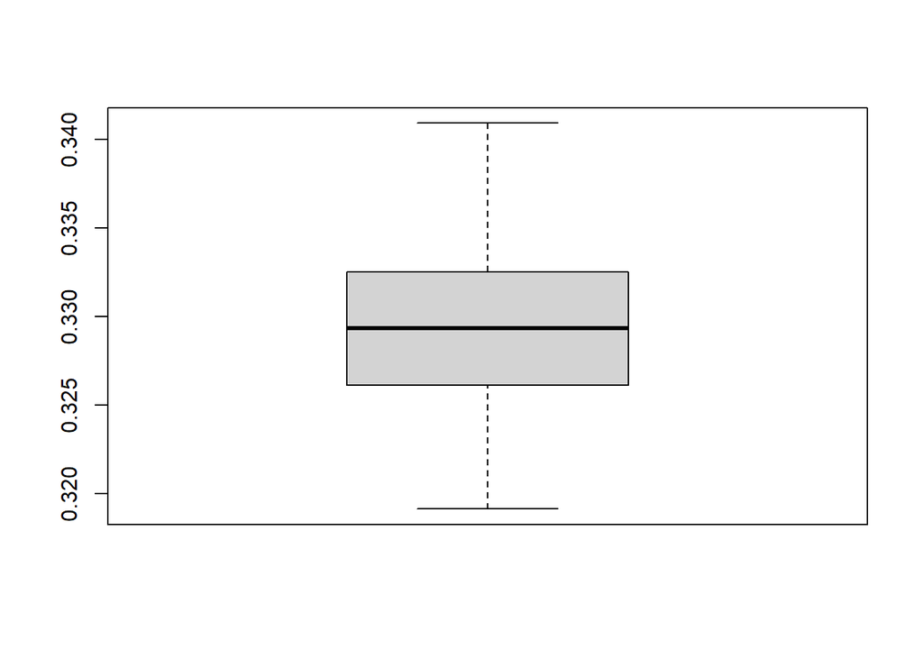

```r
boxplot(err.boot_B)
```

```r
# on fixe le nombre de voisins à considérer
K <- 70
#réalisation de la prédiction
knn_pred_qda_T_B <- knn(train = train_data_B[,-c(1,2,5,7,14)], test = valid_data_B[,-c(1,2,5,7,14)],
                cl = train_data_B[,"popularity"], k=K)
# prédiction par des probabilités
knn_pred_prob_qda_T_B <- knn(train = train_data_B[,-c(1,2,5,7,14)],
                             test = valid_data_B[,-c(1,2,5,7,14)],
                             cl = train_data_B[,"popularity"], k=K, prob = TRUE)
#matrice de confusion en test
table(valid_data_B[,1],knn_pred_qda_T_B)%>%kable()%>% kable_styling()
```

|  | haute | basse |
| --- | --- | --- |
| haute | 3078 | 94 |
| basse | 1431 | 87 |

```r
#taux d'erreur
mean(valid_data_B[,1]!=knn_pred_qda_T_B)
```

```
## [1] 0.3251599
```

### Arbre de décision :

#### Premier arbre avec paramètres max :

```r
control_max_B <- rpart.control(cp = 0, max.depth = 0, minbucket = 1, minsplit = 1)
tree_max_B <- rpart(popularity~. , data = train_data_B, control = control_max_B,
            parms = list(split = "information"))
```

#### Estimation et élagage :

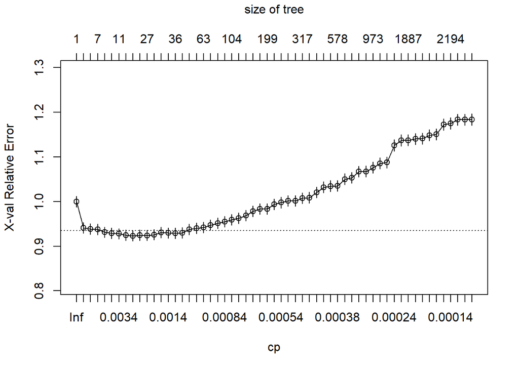

```r
plotcp(tree_max_B)
```

```r
#tree_max_B$cp
#tree_max_B$numresp
#tree_max_B$cp
```

calcul du meilleur cp :

```r
i=which.min(tree_max_B$cp[,"xerror"])
threshold_B=tree_max_B$cp[i,"xerror"]+tree_max_B$cp[i,"xstd"]
j=which(tree_max_B$cp[,"xerror"]<=threshold_B)
tree_max_B$cp[j,"CP"]%>% kable()%>% kable_styling()
```

|  | x |
| --- | --- |
| 5 | 0.0044043 |
| 6 | 0.0034133 |
| 7 | 0.0033032 |
| 8 | 0.0020553 |
| 9 | 0.0019085 |
| 10 | 0.0018058 |
| 11 | 0.0017617 |
| 12 | 0.0015415 |
| 13 | 0.0014681 |
| 14 | 0.0014314 |
| 15 | 0.0013213 |
| 16 | 0.0012479 |

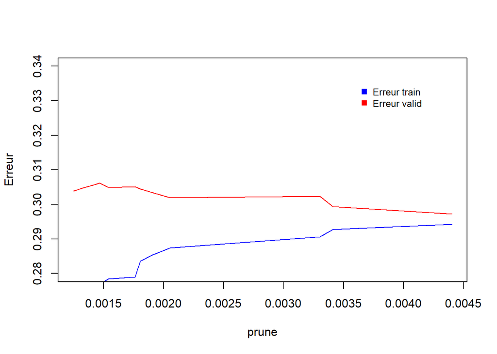

```r
liste_cp_B=as.vector(tree_max_B$cp[j,"CP"])
Error_train_seuil_B<-NULL
Error_valid_seuil_B<-NULL

for(i in 1:length(liste_cp_B)){
  tree_bis_cp_B<- prune(tree_max_B, cp = liste_cp_B[i])
  prediction_cp_B <- predict(tree_bis_cp_B, newdata = train_data_B, type = "class")
  realite_B=train_data_B$popularity
  Error_train_seuil_B[i]<-sum(prediction_cp_B!=realite_B)/nrow(train_data_B)
  prediction_cp_B2 <- predict(tree_bis_cp_B, newdata = valid_data_B, type = "class")
  realite=valid_data_B$popularity
  Error_valid_seuil_B[i]<-sum(prediction_cp_B2!=realite)/nrow(valid_data_B)
}

plot(liste_cp_B,Error_train_seuil_B,type="l",col="blue", xlab = "prune", ylab="Erreur",ylim=c(0.28,0.34))
lines(liste_cp_B,Error_valid_seuil_B,col="red")
legend('topright', legend=c("Erreur train", "Erreur valid"),
       col=c("blue", "red"), pch=15, bty="n", pt.cex=1, cex= 0.8, horiz=FALSE, inset=c(0.1,0.1))
```

```r
tree_B<- prune(tree_max_B, cp = 0.006826690)
```

```r
Prediction_tree_B<- predict(tree_B, newdata = valid_data_B, type = "class")
```

```r
control_max_B2 <- rpart.control(cp = 0.006826690, max.depth = 0, minbucket = 1, minsplit = 1)
tree_Fin_B <- rpart(popularity~. , data = train_data_B, control = control_max_B2,
            parms = list(split = "information"))
```

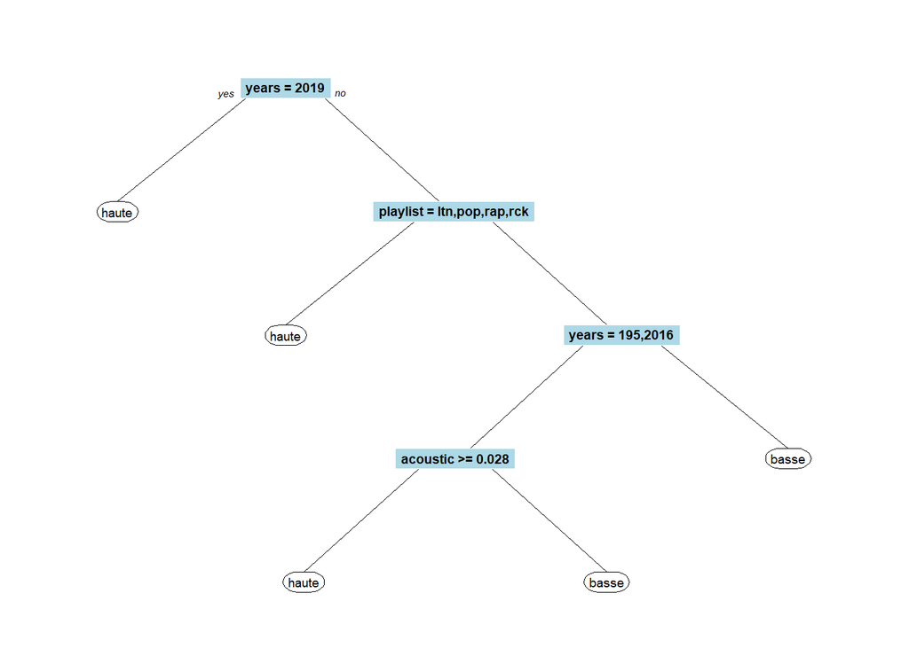

```r
prp(tree_Fin_B,type=0,extra=0,split.box.col="lightblue",cex=0.6)
```

Erreur :

```r
Realite_tree_B<-valid_data_B$popularity
MatConf_tree_B<-table(Realite_tree_B,Prediction_tree_B)
addmargins(MatConf_tree_B)%>% kable(caption = "Matrice de confusion")
```

Matrice de confusion

|  | haute | basse | Sum |
| --- | --- | --- | --- |
| haute | 2915 | 257 | 3172 |
| basse | 1148 | 370 | 1518 |
| Sum | 4063 | 627 | 4690 |

```r
N<-sum(valid_data_B$popularity=="basse")
P<-sum(valid_data_B$popularity=="haute")
Error_tree_B<-NULL
ErrorI_tree_B<-NULL
ErrorII_tree_B<-NULL


Error_tree_B<-sum(Prediction_tree_B!=Realite_tree_B)/nrow(valid_data_B)
ErrorI_tree_B<-sum((Prediction_tree_B=="haute")&(Realite_tree_B=="basse"))/N
ErrorII_tree_B<-sum((Prediction_tree_B=="basse")&(Realite_tree_B=="haute"))/P
```

#### Changement du seuil d’acceptation dans le groupe :

test avec méthode prob pour changer seuil d’acceptation des groupes :

```r
Prediction_tree_B_prob<- predict(tree_B, newdata = test_data_B, type = "prob")
```

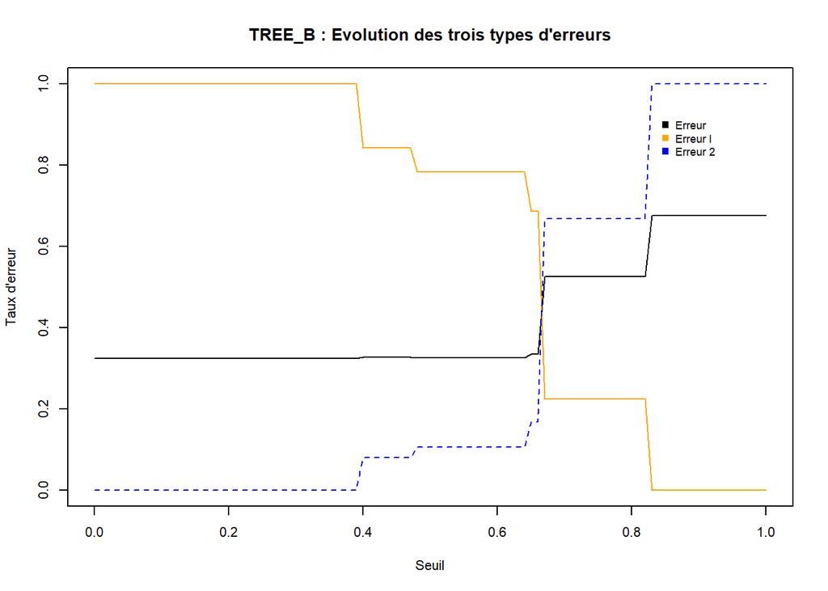

```r
N<-sum(valid_data_B=="basse")
P<-sum(valid_data_B=="haute")
Error_tree_B<-NULL
ErrorI_tree_B<-NULL
ErrorII_tree_B<-NULL
for(i in 1:101){
c<-(i-1)/100
Prediction_tree_BS<-rep("basse",nrow(valid_data_B))
Prediction_tree_BS[Prediction_tree_B_prob[,1]>c]<-"haute"
Error_tree_B[i]<-sum(Prediction_tree_BS!=Realite_lda_T_B)/nrow(valid_data_B)
ErrorI_tree_B[i]<-sum((Prediction_tree_BS=="haute")&(Realite_lda_T_B=="basse"))/N
ErrorII_tree_B[i]<-sum((Prediction_tree_BS=="basse")&(Realite_lda_T_B=="haute"))/P
}
par(cex=0.7)
plot((0:100)/100,Error_tree_B,type="l",xlim=c(0,1),ylim=c(0,1),
ylab="Taux d'erreur",xlab="Seuil")
par(new=T)
plot((0:100)/100,ErrorI_tree_B,type="l",xlim=c(0,1),ylim=c(0,1),
ylab="",xlab="",xaxt="n",yaxt="n",col="orange")
par(new=T)
plot((0:100)/100,ErrorII_tree_B,type="l",xlim=c(0,1),ylim=c(0,1),ylab="",xlab="",xaxt="n",yaxt="n",col="blue",lty="dashed")
legend('topright', legend=c("Erreur ", "Erreur I", "Erreur 2"),
       col=c("black","orange", "blue"), pch=15, bty="n", pt.cex=1, cex= 0.8, horiz=FALSE, inset=c(0.1,0.1))
title("TREE_B : Evolution des trois types d'erreurs")
```

Changement du seuil d’affectation dans “haute” :

```r
change_seuil_tree_B<-rep("basse",nrow(valid_data_B))
change_seuil_tree_B[Prediction_tree_B_prob[,1]>0.67]<-"haute"
MatConf_tree_B2<-table(Realite_qda_T_B,change_seuil_tree_B)

round(prop.table(table(Realite_qda_T_B,change_seuil_tree_B),margin=1)*100,1)%>% kable(caption = "TREE_B : matrice de confusion, seuil 0,67")%>% kable_styling()
```

TREE_B : matrice de confusion, seuil 0,67

|  | basse | haute |
| --- | --- | --- |
| haute | 66.9 | 33.1 |
| basse | 77.5 | 22.5 |

```r
N<-sum(valid_data_B=="basse")
P<-sum(valid_data_B=="haute")


round(prop.table(table(Realite_qda_T_B,Prediction_tree_B),margin=1)*100,1)
```

```
##                Prediction_tree_B
## Realite_qda_T_B haute basse
##           haute  91.9   8.1
##           basse  75.6  24.4
```

```r
Error_tree_B1<-sum(Prediction_tree_B!=Realite_lda_T_B)/nrow(valid_data_B)
ErrorI_tree_B1<-sum((Prediction_tree_B=="haute")&(Realite_lda_T_B=="basse"))/N
ErrorII_tree_B1<-sum((Prediction_tree_B=="basse")&(Realite_lda_T_B=="haute"))/P

Error_tree_B<-sum(change_seuil_tree_B!=Realite_lda_T_B)/nrow(valid_data_B)
ErrorI_tree_B<-sum((change_seuil_tree_B=="haute")&(Realite_lda_T_B=="basse"))/N
ErrorII_tree_B<-sum((change_seuil_tree_B=="basse")&(Realite_lda_T_B=="haute"))/P

matrix_error_tree_B <- as.table(matrix(round(c(Error_tree_B1, Error_tree_B, ErrorI_tree_B1, ErrorI_tree_B, ErrorII_tree_B1, ErrorII_tree_B),3), ncol = 3, nrow = 2))
rownames(matrix_error_tree_B)<- c("seuil= 0,5", "seuil= 0,67 ")
colnames(matrix_error_tree_B)<- c("Erreur", "Erreur1", "Erreur2")

kable(matrix_error_tree_B, caption = "TREE_B : comparaison des erreurs") %>% kable_styling()
```

TREE_B : comparaison des erreurs

|  | Erreur | Erreur1 | Erreur2 |
| --- | --- | --- | --- |
| seuil= 0,5 | 0.300 | 0.756 | 0.081 |
| seuil= 0,67 | 0.525 | 0.225 | 0.669 |

### Random Forest

#### Choix des meilleurs paramètres :

choix des meilleurs min.no.size et mtry avec caret :

```r
ctrlCv <- trainControl(method = "repeatedcv", repeats = 3)
rangerGrid_B <- expand.grid(mtry = c(1, 2, 4, 8, 12), min.node.size = c(10, 50, 100, 150), splitrule = "gini")
# enregistrement d'un cluster avec le package doParallel
library(doParallel)
registerDoParallel(cores = 6)
# lancement de la commande à l'identique
system.time(ranger.caret_B <- train(popularity ~ .,
  data = train_data_B, method = "ranger",
  trControl = ctrlCv, tuneGrid = rangerGrid_B
))
```

```
##    user  system elapsed
##   23.62    0.39 1501.02
```

```r
# fermeture du cluster
stopImplicitCluster()
```

```r
ranger.caret_B$bestTune%>% kable()%>%kable_styling()
```

|  | mtry | splitrule | min.node.size |
| --- | --- | --- | --- |
| 15 | 8 | gini | 100 |

Choix de la profondeur et du nombre d’arbres :

```r
set.seed((1))
nvar=ncol(data_pop_B)-1
err_par_B <- NULL
prof <- c(20,40,60,80,100)
profondeur<-c(200,300,400,500)
i <- 1
for (k in prof){
  for (l in profondeur){
  rfpro_par_B <- randomForest(popularity ~ .,
    data = train_data_B,mtry=8, method = "class", ntree = l,
    parms = list(split = "gini"), maxnodes = k, min.nodesize=100
  )
  err_par_B[i] <- rfpro_par_B$err.rate[l, 1]
  i <- i + 1
}}

tabloB <-as.table(matrix(err_par_B,nrow=4, byrow=FALSE))
colnames(tabloB)<-prof
row.names(tabloB) <- profondeur
tabloB
```

```
##            20        40        60        80       100
## 200 0.3005189 0.2967517 0.2956855 0.2957566 0.2950458
## 300 0.2995238 0.2960409 0.2963963 0.2935532 0.2939797
## 400 0.3003767 0.2978179 0.2945483 0.2949037 0.2950458
## 500 0.3017983 0.2970360 0.2961831 0.2949037 0.2936954
```

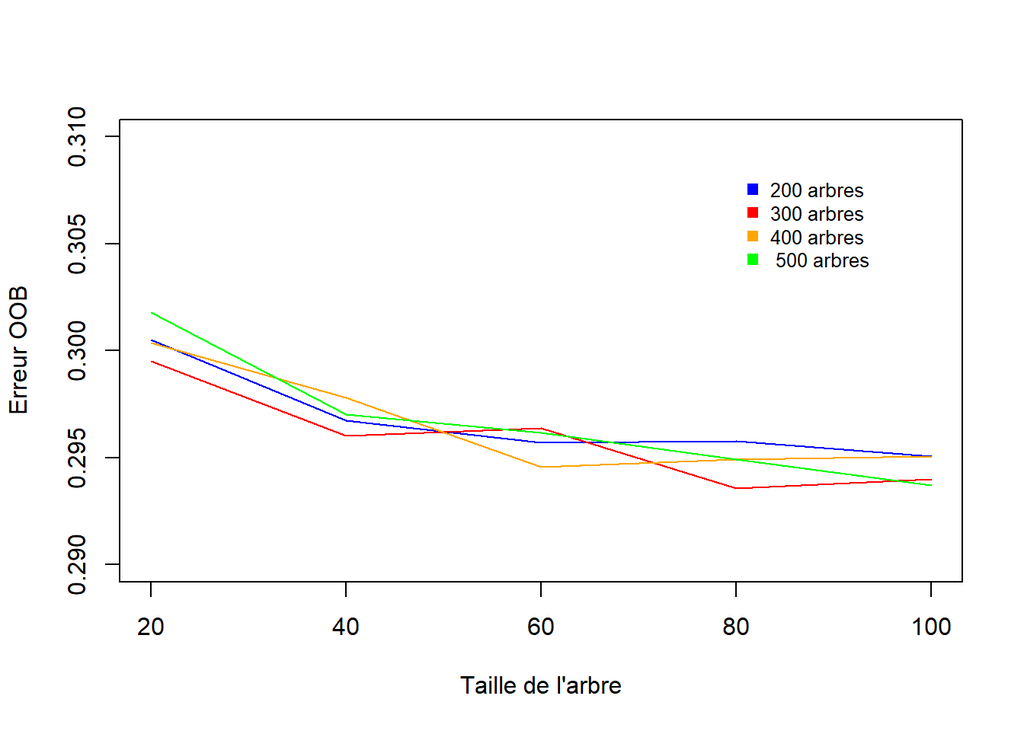

```r
plot(prof,tabloB[1,],type="l",col="blue", xlab = "Taille de l'arbre", ylab="Erreur OOB",ylim=c(0.29,0.31))
lines(prof,tabloB[2,],col="red")
lines(prof,tabloB[3,],col="orange")
lines(prof,tabloB[4,],col="green")
legend('topright', legend=c("200 arbres", "300 arbres", "400 arbres", " 500 arbres"),
col=c("blue", "red", "orange", "green"), pch=15, bty="n", pt.cex=1, cex= 0.8, horiz=FALSE, inset=c(0.1,0.1))
```

On crée le modèle avec les paramètres optimaux.

```r
rf_B <- randomForest(popularity ~ .,
  data = train_data_B, method = "class", mtry=8, method = "class", ntree = 300,
    parms = list(split = "gini"), maxnodes = 80, min.nodesize=100, na.action = na.roughfix
)
```

```r
mean(rf_B$err.rate)
```

```
## [1] 0.382796
```

#### graphiques des erreurs en fonctions de certains paramètres :

Grahiques pour tester les paramètres.

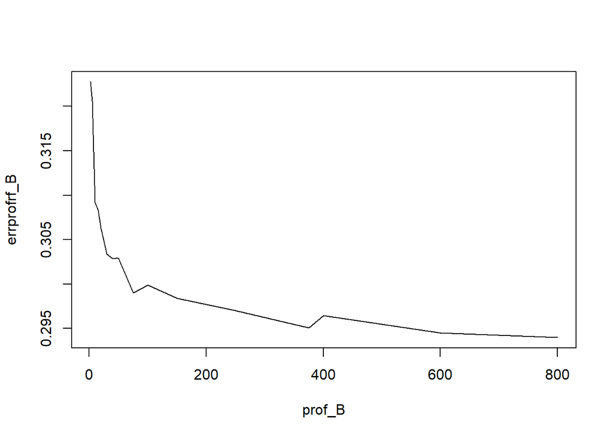

```r
# trouver le meilleur maxnodes
errprofrf_B <- NULL
prof_B <- c(2, 5, 10, 15, 20, 30, 40, 50, 75, 100, 150, 250, 375, 400, 600, 800)
i <- 1
for (k in prof_B) {
  rfpro_B <- randomForest(popularity ~ .,
    data = train_data_B, method = "class", ntree = 200,
    parms = list(split = "gini"), maxnodes = k, na.action = na.roughfix
  )
  errprofrf_B[i] <- rfpro_B$err.rate[200, 1]
  i <- i + 1
}
plot(prof_B, errprofrf_B, type = "l")
```

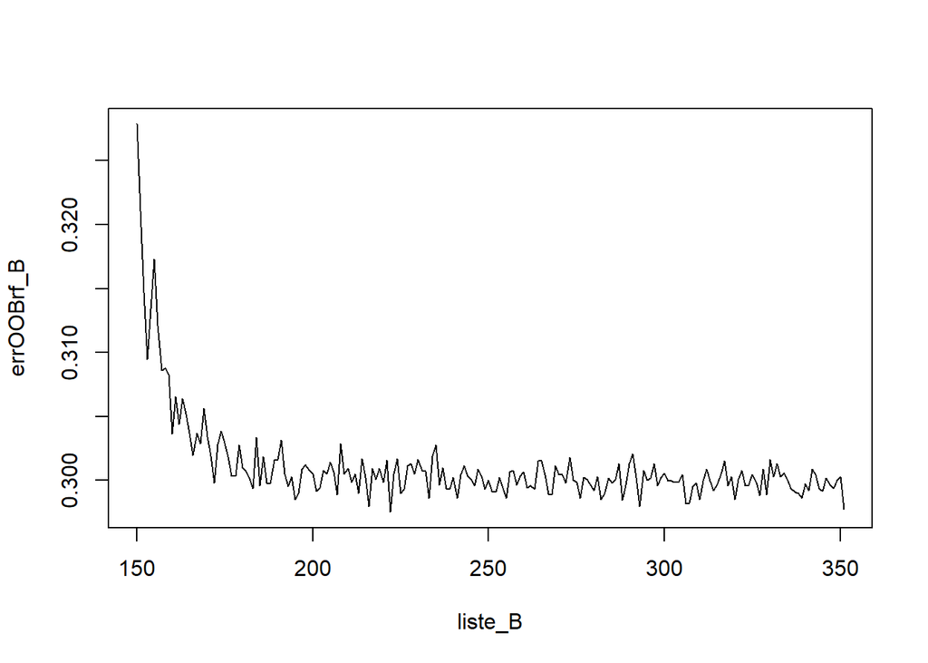

```r
#trouver le meilleur nb d'arbres (ntree)
errOOBrf_B <- NULL
i <- 1
liste_B = c(150:351)
for (k in liste_B ) {
  rf1_B <- randomForest(popularity ~ .,
    data = train_data_B, method = "class", ntree = k,
    parms = list(split = "gini"), maxnodes = 100, na.action = na.roughfix
  )
  errOOBrf_B[i] <- rf1_B$err.rate[i, 1]
  i <- i + 1
}
plot(liste_B, errOOBrf_B, type = "l")
```

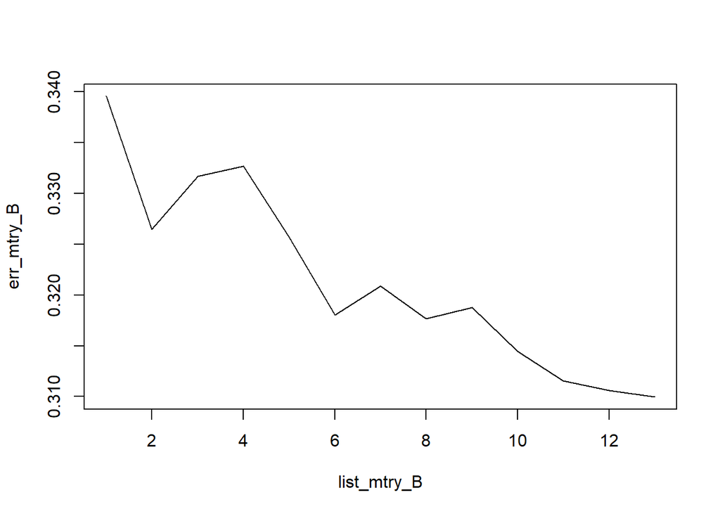

```r
# trouver le meilleur mtry :

err_mtry_B <- NULL
list_mtry_B = c(1:13)
i <- 1
for (k in list_mtry_B) {
  rf_mtry_B <- randomForest(popularity ~ .,
    data = train_data_B, method = "class", ntree = 250,
    parms = list(split = "gini"), maxnodes = 400, mtry = k, na.action = na.roughfix
  )

  err_mtry_B[i] <- rf_mtry_B$err.rate[i, 1]
  i <- i + 1
}
plot(list_mtry_B, err_mtry_B, type = "l")
```

#### Changement du seuil d’acceptation :

```r
prediction_rf_B<- predict(rf_B, newdata = valid_data_B, type = "class")
```

test avec méthode prob pour changer seuil d’acceptation des groupes :

```r
Prediction_rf_B<- predict(rf_B, newdata = valid_data_B, type = "prob")
```

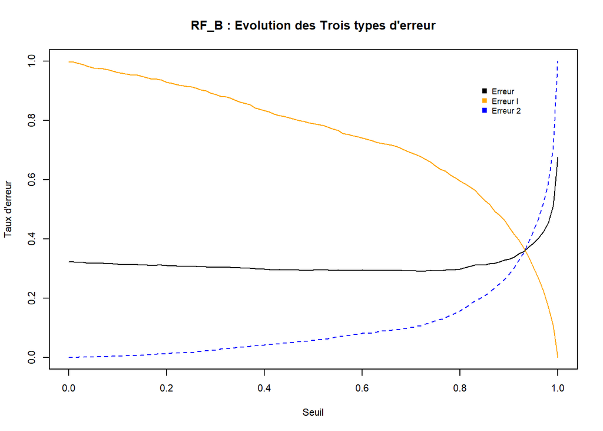

```r
N<-sum(valid_data_B=="basse")
P<-sum(valid_data_B=="haute")
Error_rf_B<-NULL
ErrorI_rf_B<-NULL
ErrorII_rf_B<-NULL
for(i in 1:101){
c<-(i-1)/100
Prediction_rf_BS<-rep("basse",nrow(valid_data_B))
Prediction_rf_BS[Prediction_rf_B[,1]>c]<-"haute"
Error_rf_B[i]<-sum(Prediction_rf_BS!=Realite_lda_T_B)/nrow(valid_data_B)
ErrorI_rf_B[i]<-sum((Prediction_rf_BS=="haute")&(Realite_lda_T_B=="basse"))/N
ErrorII_rf_B[i]<-sum((Prediction_rf_BS=="basse")&(Realite_lda_T_B=="haute"))/P
}
par(cex=0.7)
plot((0:100)/100,Error_rf_B,type="l",xlim=c(0,1),ylim=c(0,1),
ylab="Taux d'erreur",xlab="Seuil")
par(new=T)
plot((0:100)/100,ErrorI_rf_B,type="l",xlim=c(0,1),ylim=c(0,1),
ylab="",xlab="",xaxt="n",yaxt="n",col="orange")
par(new=T)
plot((0:100)/100,ErrorII_rf_B,type="l",xlim=c(0,1),ylim=c(0,1),ylab="",xlab="",xaxt="n",yaxt="n",col="blue",lty="dashed")
legend('topright', legend=c("Erreur ", "Erreur I", "Erreur 2"),
       col=c("black","orange", "blue"), pch=15, bty="n", pt.cex=1, cex= 0.8, horiz=FALSE, inset=c(0.1,0.1))
title("RF_B : Evolution des Trois types d'erreur")
```

```r
change_seuil_rf_B<-rep("basse",nrow(valid_data_B))
change_seuil_rf_B[Prediction_rf_B[,1]>0.93]<-"haute"
MatConf_rf_B2<-table(Realite_qda_T_B,change_seuil_rf_B)
round(prop.table(table(Realite_qda_T_B,change_seuil_rf_B),margin=1)*100,1)%>%kable(caption = "matrice de confusion seuil 0,93")%>% kable_styling()
```

matrice de confusion seuil 0,93

|  | basse | haute |
| --- | --- | --- |
| haute | 35.2 | 64.8 |
| basse | 63.0 | 37.0 |

```r
round(prop.table(table(Realite_qda_T_B,prediction_rf_B),margin=1)*100,1)%>%kable(caption = "matrice de confusion seuil 0,5")%>% kable_styling()
```

matrice de confusion seuil 0,5

|  | haute | basse |
| --- | --- | --- |
| haute | 94.2 | 5.8 |
| basse | 79.0 | 21.0 |

```r
N<-sum(valid_data_B=="basse")
P<-sum(valid_data_B=="haute")


Error_rf_B1<-sum(prediction_rf_B!=Realite_lda_T_B)/nrow(valid_data_B)
ErrorI_rf_B1<-sum((prediction_rf_B=="haute")&(Realite_lda_T_B=="basse"))/N
ErrorII_rf_B1<-sum((prediction_rf_B=="basse")&(Realite_lda_T_B=="haute"))/P

Error_rf_B<-sum(change_seuil_rf_B!=Realite_lda_T_B)/nrow(valid_data_B)
ErrorI_rf_B<-sum((change_seuil_rf_B=="haute")&(Realite_lda_T_B=="basse"))/N
ErrorII_rf_B<-sum((change_seuil_rf_B=="basse")&(Realite_lda_T_B=="haute"))/P


matrix_error_rf_B <- as.table(matrix(round(c(Error_rf_B1, Error_rf_B, ErrorI_rf_B1, ErrorI_rf_B, ErrorII_rf_B1, ErrorII_rf_B),3), ncol = 3, nrow = 2))
rownames(matrix_error_rf_B)<- c("seuil= 0,5", "seuil= 0,93 ")
colnames(matrix_error_rf_B)<- c("Erreur", "Erreur1", "Erreur2")

kable(matrix_error_rf_B, caption = "comparaison des erreurs") %>% kable_styling()
```

comparaison des erreurs

|  | Erreur | Erreur1 | Erreur2 |
| --- | --- | --- | --- |
| seuil= 0,5 | 0.295 | 0.79 | 0.058 |
| seuil= 0,93 | 0.358 | 0.37 | 0.352 |

Il est difficile de trouver un seuil acceptable car les taux d’erreurs changent “rapidement” autour de la valeur d’équilibre des trois erreurs. L’arbitrage est difficile à réaliser. On préfère le modèle rf93 qui prédit globalement moins bien mais dont l’erreur de type 1 est raisonnable.

### Comparaison entre les différents types de modèle :

Comparons les différents modèles à l’aide des données test.

```r
N<-sum(test_data_B=="basse")
P<-sum(test_data_B=="haute")
res_lda_seuil_B<-predict(lda_T_B,newdata=test_data_B, type ="prob")
Prediction_B_seuilLDA<-rep("basse",nrow(test_data_B))
Prediction_B_seuilLDA[res_lda_seuil_B$posterior[,1]>0.7]<-"haute"
Error_lda_seuil_B<-sum(Prediction_B_seuilLDA!=test_data_B$popularity)/nrow(test_data_B)
ErrorI_lda_seuil_B<-sum((Prediction_B_seuilLDA=="haute")&(test_data_B$popularity=="basse"))/N
ErrorII_lda_seuil_B<-sum((Prediction_B_seuilLDA=="basse")&(test_data_B$popularity=="haute"))/P
```

```r
N<-sum(valid_data_B=="basse")
P<-sum(valid_data_B=="haute")
res_qda_seuil_B<-predict(qda_T_B,newdata=test_data_B)
Prediction_B_seuilQDA<-rep("basse",nrow(test_data_B))
Prediction_B_seuilQDA[res_qda_seuil_B$posterior[,1]>0.7]<-"haute"
Error_qda_seuil_B<-sum(res_qda_seuil_B$class!=test_data_B$popularity)/nrow(test_data_B)
ErrorI_qda_seuil_B<-sum((res_qda_seuil_B$class=="haute")&(test_data_B$popularity=="basse"))/N
ErrorII_qda_seuil_B<-sum((res_qda_seuil_B$class=="basse")&(test_data_B$popularity=="haute"))/P
```

```r
N<-sum(test_data_B=="basse")
P<-sum(test_data_B=="haute")
best_rpart_control_B <- rpart.control(cp = 0.006826690, max.depth = 0,
                              minbucket = 1, minsplit = 1)
best_tree_B <- rpart(popularity ~ .,
  data = train_data_B, control = best_rpart_control_B,
  parms = list(split = "information")
)

res_best_tree_B<-predict(best_tree_B,newdata=test_data_B, type = "prob")
Prediction_B_seuilTREE<-rep("basse",nrow(test_data_B))
Prediction_B_seuilTREE[res_best_tree_B[,1]>0.67]<-"haute"
Error_best_tree_B<-sum(Prediction_B_seuilTREE!=test_data_B$popularity)/nrow(test_data_B)
ErrorI_best_tree_B<-sum((Prediction_B_seuilTREE=="haute")&(test_data_B$popularity=="basse"))/N
ErrorII_best_tree_B<-sum((Prediction_B_seuilTREE=="basse")&(test_data_B$popularity=="haute"))/P
```

```r
N<-sum(test_data_B=="basse")
P<-sum(test_data_B=="haute")
best_rf_B <-randomForest(popularity ~ .,
  data = train_data_B, method = "class", mtry=8, method = "class", ntree = 300,
    parms = list(split = "gini"), maxnodes = 80, min.nodesize=100, na.action = na.roughfix
)

res_best_rf_B<-predict(best_rf_B,newdata=test_data_B, type ="prob")
Prediction_B_seuilRF<-rep("basse",nrow(test_data_B))
Prediction_B_seuilRF[res_best_rf_B[,1]>0.92]<-"haute"
Error_best_rf_B<-sum(Prediction_B_seuilRF!=test_data_B$popularity)/nrow(test_data_B)
ErrorI_best_rf_B<-sum((Prediction_B_seuilRF=="haute")&(test_data_B$popularity=="basse"))/N
ErrorII_best_rf_B<-sum((Prediction_B_seuilRF=="basse")&(test_data_B$popularity=="haute"))/P
```

```r
erreursB <- matrix(c(Error_lda_seuil_B, Error_qda_seuil_B, Error_best_tree_B, Error_best_rf_B,
                    ErrorI_lda_seuil_B, ErrorI_qda_seuil_B, ErrorI_best_tree_B, ErrorI_best_rf_B,
                    ErrorII_lda_seuil_B, ErrorII_qda_seuil_B, ErrorII_best_tree_B, ErrorII_best_rf_B), byrow = FALSE, ncol = 3)
colnames(erreursB) <- c("Erreur globale", "Erreur type I", "Erreur type 2")
rownames(erreursB) <- c("lda70", "qda65", "tree67", "rf92")
erreursB %>% knitr::kable(digits = 3) %>%
  kableExtra::kable_styling()
```

[output not shown]

## Découpage haut :

```r
popularity <- cut(data$track_popularity, c(-1,70,100))
data_pop_H=cbind(popularity,data)
data_pop_H<-data_pop_H[,-5]
data_pop_H$popularity <- recode_factor(data_pop_H$popularity,
"(70,100]" = "haute",
"(-1,70]" = "basse")
data_pop_H<-data_pop_H[,-c(2,3,4,5,6,7,8,9,11)]
```

```r
test_data_H <- data_pop_H[ind2.te,]
train_data_H <- data_pop_H[ind2.tr,]
valid_data_H <- data_pop_H[ind2.v,]
```

### LDA : Linear discriminant analysis

```r
lda_T_H<-lda(popularity~.,data=train_data_H)
```

```r
res_lda_T_H<-predict(lda_T_H,newdata=valid_data_H)
```

#### Matrice de confusion :

```r
prediction_lda_T_H<-res_lda_T_H$class
Realite_lda_T_H<- valid_data_H$popularity
MatConf_lda_T_H<-table(Realite_lda_T_H,prediction_lda_T_H)

round(prop.table(table(Realite_lda_T_H,prediction_lda_T_H),margin=1)*100,1)%>%kable(caption = "LDA_T : matrice de confusion seuil 0,5")%>% kable_styling()
```

LDA_T : matrice de confusion seuil 0,5

|  | haute | basse |
| --- | --- | --- |
| haute | 0.6 | 99.4 |
| basse | 0.1 | 99.9 |

#### Choix du meilleur seuil :

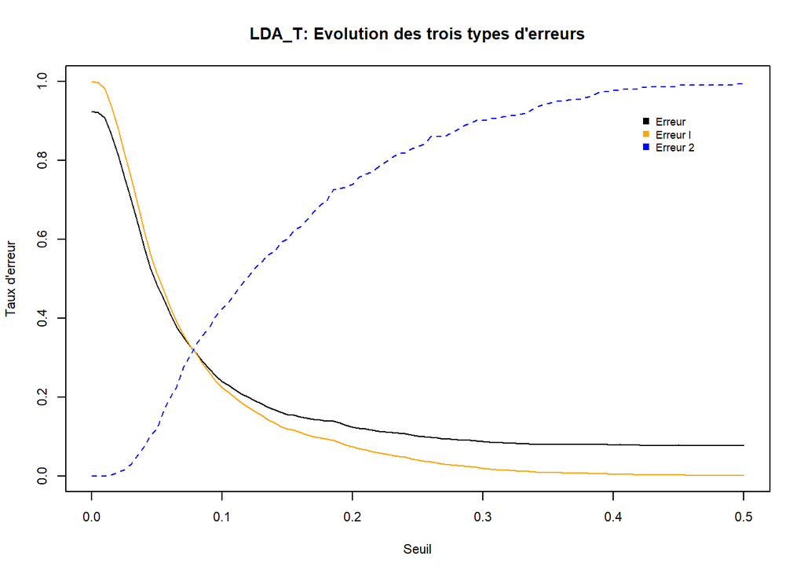

```r
N<-sum(valid_data_H=="basse")
P<-sum(valid_data_H=="haute")
Error_lda_T_H<-NULL
ErrorI_lda_T_H<-NULL
ErrorII_lda_T_H<-NULL
for(i in 1:101){
c<-(i-1)/200
Prediction_lda_T_H<-rep("basse",nrow(valid_data_H))
Prediction_lda_T_H[res_lda_T_H$posterior[,1]>c]<-"haute"
Error_lda_T_H[i]<-sum(Prediction_lda_T_H!=Realite_lda_T_H)/nrow(valid_data_H)
ErrorI_lda_T_H[i]<-sum((Prediction_lda_T_H=="haute")&(Realite_lda_T_H=="basse"))/N
ErrorII_lda_T_H[i]<-sum((Prediction_lda_T_H=="basse")&(Realite_lda_T_H=="haute"))/P
}
par(cex=0.7)
plot((0:100)/200,Error_lda_T_H,type="l",xlim=c(0,0.5),ylim=c(0,1),
ylab="Taux d'erreur",xlab="Seuil")
par(new=T)
plot((0:100)/200,ErrorI_lda_T_H,type="l",xlim=c(0,0.5),ylim=c(0,1),
ylab="",xlab="",xaxt="n",yaxt="n",col="orange")
par(new=T)
plot((0:100)/200,ErrorII_lda_T_H,type="l",xlim=c(0,0.5),ylim=c(0,1),ylab="",xlab="",xaxt="n",yaxt="n",col="blue",lty="dashed")
legend('topright', legend=c("Erreur ", "Erreur I", "Erreur 2"),
       col=c("black","orange", "blue"), pch=15, bty="n", pt.cex=1, cex= 0.8, horiz=FALSE, inset=c(0.1,0.1))
title("LDA_T: Evolution des trois types d'erreurs")
```

On choisit le meilleur seuil en fonction du graphique ci dessus.

```r
change_seuil_lda_T_H<-rep("basse",nrow(valid_data_H))
change_seuil_lda_T_H[res_lda_T_H$posterior[,1]>0.07]<-"haute"
MatConf_lda_lda_T_H<-table(Realite_lda_T_H,change_seuil_lda_T_H)
addmargins(MatConf_lda_T_H)
```

```
##                prediction_lda_T_H
## Realite_lda_T_H haute basse  Sum
##           haute     2   356  358
##           basse     5  4327 4332
##           Sum       7  4683 4690
```

```r
round(prop.table(table(Realite_lda_T_H,change_seuil_lda_T_H),margin=1)*100,1)%>%kable(caption = "LDA_T : matrice de confusion seuil 0,07")%>% kable_styling()
```

LDA_T : matrice de confusion seuil 0,07

|  | basse | haute |
| --- | --- | --- |
| haute | 27.4 | 72.6 |
| basse | 64.1 | 35.9 |

On compare les matrices de confusions :

```r
N<-sum(valid_data_H=="basse")
P<-sum(valid_data_H=="haute")
round(prop.table(table(Realite_lda_T_H,change_seuil_lda_T_H),margin=1)*100,1)
```

```
##                change_seuil_lda_T_H
## Realite_lda_T_H basse haute
##           haute  27.4  72.6
##           basse  64.1  35.9
```

```r
round(prop.table(table(Realite_lda_T_H,prediction_lda_T_H),margin=1)*100,1)
```

```
##                prediction_lda_T_H
## Realite_lda_T_H haute basse
##           haute   0.6  99.4
##           basse   0.1  99.9
```

```r
Error_lda_T_H0<-sum(Prediction_lda_T_H!=Realite_lda_T_H)/nrow(valid_data_H)
ErrorI_lda_T_H0<-sum((Prediction_lda_T_H=="haute")&(Realite_lda_T_H=="basse"))/N
ErrorII_lda_T_H0<-sum((Prediction_lda_T_H=="basse")&(Realite_lda_T_H=="haute"))/P

Error_lda_T_HS<-sum(change_seuil_lda_T_H!=Realite_lda_T_H)/nrow(valid_data_H)
ErrorI_lda_T_HS<-sum((change_seuil_lda_T_H=="haute")&(Realite_lda_T_H=="basse"))/N
ErrorII_lda_T_HS<-sum((change_seuil_lda_T_H=="basse")&(Realite_lda_T_H=="haute"))/P

matrix_error_lda_H <- as.table(matrix(round(c(Error_lda_T_H0, Error_lda_T_HS, ErrorI_lda_T_H0, ErrorI_lda_T_HS, ErrorII_lda_T_H0, ErrorII_lda_T_HS),3), ncol = 3, nrow = 2))
rownames(matrix_error_lda_H)<- c("seuil= 0,5", "seuil= 0,08")
colnames(matrix_error_lda_H)<- c("Erreur", "Erreur1", "Erreur2")

kable(matrix_error_lda_H, caption = "comparaison des erreurs") %>% kable_styling()
```

comparaison des erreurs

[output not shown]

#### Courbe ROC.

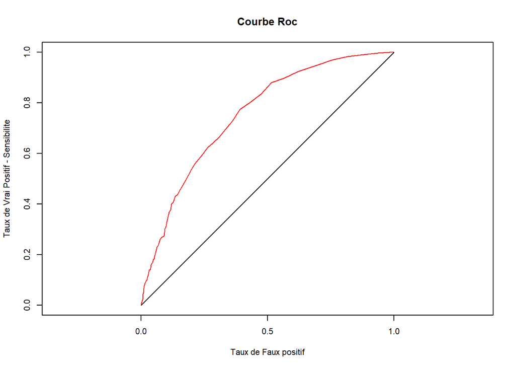

```r
par(cex=0.7)
plot(c(ErrorI_lda_T_H,0),c(1-ErrorII_lda_T_H,0),main="Courbe Roc",
ylab="Taux de Vrai Positif - Sensibilite",
xlab="Taux de Faux positif",type="l",asp=1,col="red",xlim=c(0,1),ylim=c(0,1))
segments(0,0,1,1)
```